# Co se změní, když přidáme prediktor?

Model s více prediktory na klimatických datech křídlatky

Publikováno

23. srpna 2026

Upraveno

21. října 2026

## 1 Úvod

V předchozích lekcích jsme pracovali s lineárním modelemStatistický model, v němž je průměrná odezva součtem interceptu a prediktorů násobených koeficienty; lineární je v koeficientech, takže nemusí jít jen o přímku., který měl jediný prediktorProměnná, pomocí níž vysvětlujeme variabilitu odezvy; v notaci y ~ x je prediktor x.. NumerickýProměnná, jejíž hodnoty jsou čísla se smysluplnou velikostí nebo rozdílem; může být diskrétní, například počet, nebo spojitá, například délka. prediktor, například zeměpisná šířka, nám dal sklonParametr lineárního modelu udávající, o kolik se v průměru liší odezva dvou pozorování, jejichž prediktor se liší o jednu jednotku (při stejných hodnotách ostatních prediktorů).: o kolik se v průměru liší odezvaProměnná, jejíž variabilitu se snažíme vysvětlit nebo předpovědět; v notaci modelu y ~ x je odezva y. při rozdílu prediktoru o jednu jednotku. KategoriálníProměnná nabývající hodnot z omezeného počtu kategorií; může být nominální (bez pořadí) nebo ordinální (s pořadím). prediktor, například druh tučňáka, nám dal rozdíly mezi skupinami vůči referenční skupiněÚroveň kategoriálního prediktoru, vůči které model vyjadřuje rozdíly ostatních skupin; její průměr (při nulových numerických prediktorech) je intercept.. Biologické vlastnosti se ale v přírodě obvykle nemění jedna po druhé. Teplé místo bývá zároveň místem s horkým létem, jiným úhrnem srážek a někdy i jinou historií populací.

Budeme sledovat křídlatku japonskou (*Reynoutria japonica*), jednu z nejznámějších invazních rostlin Evropy i Severní Ameriky. Výzkumníci odebrali oddenky populací z původního areálu ve východní Asii i ze zavlečeného areálu a pěstovali je vedle sebe ve **společné zahradě**. Všechny rostliny tak rostly ve stejném aktuálním prostředí a rozdíly mezi nimi mohou odrážet hlavně to, odkud populace pocházejí.

**QuestionHlavní otázka této lekce**

**Mění klima původu tloušťku listů křídlatky?**

**QuestionCo čekáte ještě před prvním grafem?**

Představte si, že populace z teplejších míst mají v průměru tenčí listy. Znamená to už, že teplo listy ztenčuje? Co dalšího se může s teplotou místa původu měnit zároveň?

**DůležitéMožná odpověď**

Samotná souvislost ještě nevysvětluje proč. S teplotou se obvykle mění i další části klimatu, například nejteplejší měsíc nebo srážky. Teplá a chladná místa se navíc mohou lišit tím, zda jde o původní, nebo zavlečené populace s odlišnou historií. Všechny tyto vlastnosti se mohou měnit společně. V této lekci uvidíme, jak takové souběžné vlastnosti zapojit do jednoho modelu a jak se tím změní otázka, na kterou model odpovídá.

## 2 Výsledky učení

Po prostudování této lekce budete schopni:

- fitovat aditivní lineární modelStatistický model, v němž je průměrná odezva součtem interceptu a prediktorů násobených koeficienty; lineární je v koeficientech, takže nemusí jít jen o přímku. s více prediktoryProměnná, pomocí níž vysvětlujeme variabilitu odezvy; v notaci y ~ x je prediktor x. a vyložit každý koeficient „při stejných hodnotách ostatních prediktorů“;
- vysvětlit, proč se odhadČíslo vypočtené z pozorovaných dat jako přiblížení neznámé vlastnosti nebo parametru; jiný srovnatelný výběr může dát jiný odhad. efektuKvantitativní popis toho, jak se podle modelu mění odezva s prediktorem; zahrnuje směr, velikost a nejistotu odhadu, ale sám o sobě nedokládá příčinu. po přidání prediktoru může změnit, a odlišit celkový a podmíněný vztah;
- rozpoznat silně korelované prediktorySituace, kdy dva nebo více prediktorů v modelu navzájem korelují; silná korelace způsobuje nestabilitu odhadů. a popsat, jak zvyšují nejistotuRozsah, v němž nevíme přesnou hodnotu parametru kvůli omezenému výběru a výběrové variabilitě; kvantifikuje se pomocí standardních chyb a intervalů spolehlivosti. a komplikují výklad;
- porovnat skupiny a vytvářet predikceHodnota odezvy, kterou model odhaduje pro nové pozorování nebo pro zvolenou kombinaci prediktorů, která nebyla mezi daty použitými k odhadu modelu. jen pro kombinace hodnot podložené daty;
- odlišit test koeficientu v `summary()` od sekvenčního testu v `anova()`.

## 3 Každý řádek je jedna zdrojová populace

Data pocházejí ze studie Cao et al. (2025). Autoři pěstovali populace křídlatky z Číny, Japonska, Evropy a Severní Ameriky ve dvou společných zahradách v Číně; my používáme zahradu v Šanghaji. Tloušťku listů jednotlivých rostlin jsme zprůměrovali za každou populaci. Klimatické údaje o místě původu každé populace jsme doplnili z otevřeného souboru CHELSA-BIOCLIM 2.1, který shrnuje dlouhodobé klima let 1981–2010.

Soubor kridlatka_populace.csv je součástí materiálů. Pro následující kód jej uložte do složky `data` ve svém projektu v R. Načteme ho a zkontrolujeme názvy a typy sloupců:

```r
# Načteme tabulku s jedním řádkem pro každou zdrojovou populaci
data_kridlatka <-
  read.csv(file = "data/kridlatka_populace.csv")

# Zkontrolujeme názvy a typy sloupců
str(object = data_kridlatka)
```

```
'data.frame':   128 obs. of  14 variables:
 $ populace                : chr  "CN1" "CN10" "CN11" "CN12" ...
 $ oblast                  : chr  "CN" "CN" "CN" "CN" ...
 $ puvod                   : chr  "Puvodni" "Puvodni" "Puvodni" "Puvodni" ...
 $ zemepisna_sirka         : num  29.3 26.8 26.6 26.3 26 ...
 $ zemepisna_delka         : num  118 116 116 116 116 ...
 $ tloustka_listu_mm       : num  0.346 0.343 0.323 0.328 0.323 ...
 $ teplota_rocni_C         : num  18.3 18.9 18.1 19.1 19.6 ...
 $ teplota_sezonnost       : num  818 771 706 712 720 ...
 $ teplota_max_C           : num  32.9 33.1 31.3 32.1 33 ...
 $ teplota_min_C           : num  1.65 2.45 2.45 3.05 3.35 ...
 $ srazky_rocni_mm         : num  2073 1874 2484 1906 1945 ...
 $ srazky_nejvlhci_mesic_mm: num  382 325 421 323 317 ...
 $ srazky_nejsussi_mesic_mm: num  52.8 46.8 60.3 45.6 47.3 43.9 37.4 38.3 41.7 42.1 ...
 $ srazky_sezonnost        : num  56.5 58.1 58.4 59.6 59.2 56.6 55 54.6 54.9 56.5 ...
```

Sloupec `puvod` obsahuje text `Puvodni` nebo `Zavleceny`. Převedeme ho na faktor a pořadím úrovníJedna z kategorií kategoriální proměnné uložené v R jako faktor, například jeden druh z proměnné druh. určíme, že referenční skupinouÚroveň kategoriálního prediktoru, vůči které model vyjadřuje rozdíly ostatních skupin; její průměr (při nulových numerických prediktorech) je intercept. budou původní populace. Potom zkontrolujeme rozsahy sloupců, které použijeme v modelech, a chybějící hodnoty:

```r
# Původ převedeme na faktor; první úroveň bude referenční skupinou
data_kridlatka$puvod <-
  factor(
    x = data_kridlatka$puvod,
    levels = c("Puvodni", "Zavleceny")
  )

# Počet populací v původním a zavlečeném areálu
table(data_kridlatka$puvod)
```

```
  Puvodni Zavleceny
       55        73
```

```r
# Vybereme sloupce, které použijeme v hlavních modelech
vec_sloupce_modelu <-
  c("tloustka_listu_mm", "teplota_rocni_C", "teplota_max_C", "puvod")

# Minimum, kvartily, průměr a maximum vybraných sloupců
summary(object = data_kridlatka[, vec_sloupce_modelu])
```

```
 tloustka_listu_mm teplota_rocni_C teplota_max_C         puvod
 Min.   :0.2922    Min.   : 5.95   Min.   :19.25   Puvodni  :55
 1st Qu.:0.3353    1st Qu.: 9.25   1st Qu.:23.52   Zavleceny:73
 Median :0.4180    Median :12.60   Median :27.90
 Mean   :0.3928    Mean   :12.89   Mean   :27.17
 3rd Qu.:0.4401    3rd Qu.:17.12   3rd Qu.:30.77
 Max.   :0.5192    Max.   :19.95   Max.   :33.95
```

```r
# Počet chybějících hodnot v každém sloupci
colSums(x = is.na(x = data_kridlatka))
```

```
                populace                   oblast                    puvod
                       0                        0                        0
         zemepisna_sirka          zemepisna_delka        tloustka_listu_mm
                       0                        0                        0
         teplota_rocni_C        teplota_sezonnost            teplota_max_C
                       0                        0                        0
           teplota_min_C          srazky_rocni_mm srazky_nejvlhci_mesic_mm
                       0                        0                        0
srazky_nejsussi_mesic_mm         srazky_sezonnost
                       0                        0
```

Tabulka obsahuje 128 populací: 55 z původního a 73 ze zavlečeného areálu. Žádný sloupec nemá chybějící hodnoty. Průměrná tloušťka listu se pohybuje od 0,29 do 0,52 mm a průměrná roční teplota místa původu od 5,95 do 19,95 °C. Takové hodnoty odpovídají listům bylin i klimatu mírného a subtropického pásu, takže nic nenaznačuje chybu jednotek. Rozsahy teplot zároveň vymezují podmínky, pro které jsou pozdější predikceHodnota odezvy, kterou model odhaduje pro nové pozorování nebo pro zvolenou kombinaci prediktorů, která nebyla mezi daty použitými k odhadu modelu. podložené daty.

Význam jednotlivých sloupců je:

| Sloupec | Co obsahuje | Role v analýze |
| --- | --- | --- |
| `populace` | identifikátor zdrojové populace | jednotka pozorováníEntita nebo děj, o kterém jedno pozorování nese informace, například jedinec, plocha, vzorek vody nebo jedna erupce. |
| `oblast` | země nebo oblast původu | popis |
| `puvod` | původní nebo zavlečený areál | potenciální kategoriální prediktorProměnná, pomocí níž vysvětlujeme variabilitu odezvy; v notaci y ~ x je prediktor x. |
| `zemepisna_sirka`, `zemepisna_delka` | souřadnice místa původu | popis |
| `tloustka_listu_mm` | průměrná tloušťka listu v mm | odezvaProměnná, jejíž variabilitu se snažíme vysvětlit nebo předpovědět; v notaci modelu y ~ x je odezva y. |
| `teplota_rocni_C` | průměrná roční teplota v °C | potenciální numerický klimatický prediktor |
| `teplota_sezonnost` | proměnlivost teplot během roku | potenciální numerický klimatický prediktor |
| `teplota_max_C` | maximum teploty nejteplejšího měsíce v °C | potenciální numerický klimatický prediktor |
| `teplota_min_C` | minimum teploty nejchladnějšího měsíce v °C | potenciální numerický klimatický prediktor |
| `srazky_rocni_mm` | roční úhrn srážek v mm | potenciální numerický klimatický prediktor |
| `srazky_nejvlhci_mesic_mm` | srážky nejvlhčího měsíce v mm | potenciální numerický klimatický prediktor |
| `srazky_nejsussi_mesic_mm` | srážky nejsuššího měsíce v mm | potenciální numerický klimatický prediktor |
| `srazky_sezonnost` | proměnlivost srážek během roku | potenciální numerický klimatický prediktor |

**QuestionCo je jednotkou analýzy?**

Rostliny ze stejné populace mají stejné klima původu. Proč by bylo chybou analyzovat všechny rostliny jako nezávislá pozorováníJeden zaznamenaný případ v datech, který obsahuje hodnoty jedné nebo více proměnných. klimatu?

**DůležitéMožná odpověď**

Klimatický prediktor se mění jen mezi populacemi, nikoli mezi rostlinami jedné populace. Několik rostlin z jednoho místa nepřináší několik nezávislých informací o klimatu, ale jedenkrát totéž klima. Kdybychom je počítali jako samostatná pozorování, nadhodnotili bychom množství informace a model by působil přesněji, než ve skutečnosti je. Proto je jedním řádkem a jednou jednotkou analýzy zdrojová populace.

**TipDoplňující: stažení a příprava dat**

Pro běžnou práci používáme hotovou lokální tabulku, takže není potřeba internetové připojení. Volitelný postup níže umožňuje celý vznik tabulky zopakovat: stáhne původní znaky z repozitáře Dryad, ověří soubor, získá klimatická data CHELSA a spojí oba zdroje. Jednotlivé rostliny shrneme na úroveň populace, protože klima se mezi rostlinami stejné populace nemění. Pokud automatické stažení z Dryad selže, stáhněte soubor herb-trait.csv ze [stránky datasetu](https://datadryad.org/dataset/doi%3A10.5061/dryad.qbzkh18r4) ručně do složky data-raw; kontrolní součet v kódu ověří správnou verzi.

**Zobrazit kompletní stažení a přípravu dat**

```r
# Balíčky stačí nainstalovat jednou:
# install.packages(pkgs = c("digest", "here", "terra"))

# 1. Připravíme adresáře pro stažená a výsledná data
soubor_znaky <- here::here("data-raw", "herb-trait.csv")
soubor_vyuka <- here::here("data", "kridlatka_populace.csv")

dir.create(path = dirname(path = soubor_znaky), recursive = TRUE, showWarnings = FALSE)
dir.create(path = dirname(path = soubor_vyuka), recursive = TRUE, showWarnings = FALSE)

# 2. Stáhneme původní tabulku znaků přímo z Dryad
url_znaky <- "https://datadryad.org/downloads/file_stream/3893167"

if (
  !file.exists(soubor_znaky)) {
  download.file(
    url = url_znaky,
    destfile = soubor_znaky,
    mode = "wb"
  )
}

# Kontrolní součet odhalí neúplné nebo později změněné stažení
sha256_ocekavany <- paste0(
  "c6a5afae067597870156fc1fe4b8e688",
  "3784d5eb40f967a2ca95dde6d4fc74a8"
)
sha256_stazeny <- digest::digest(
  object = soubor_znaky,
  algo = "sha256",
  file = TRUE
)

stopifnot(identical(x = sha256_stazeny, y = sha256_ocekavany))

# 3. Načteme tabulku a dáme sloupcům krátké pracovní názvy
data_znaky <- read.csv(
  file = soubor_znaky,
  check.names = FALSE
)

names(data_znaky) <- c(
  "garden", "range", "population", "individual", "latitude", "longitude",
  "block", "root_weight_g", "source", "leaf_thickness_mm",
  "leaf_toughness_n", "leaf_cn", "alkaloids_mg_g", "flavonoids_mg_g",
  "lignin_mg_g", "herb_beetle_pct", "herb_caterpillar_pct"
)

# 4. Vybereme šanghajskou zahradu a vytvoříme průměr za populaci
data_znaky_shanghai <- data_znaky[data_znaky$garden == "SH", ]

data_populace <- aggregate(
  x = leaf_thickness_mm ~ population + range + source + latitude + longitude,
  data = data_znaky_shanghai,
  FUN = mean
)

# 5. Otevřeme osm vrstev CHELSA-BIOCLIM 2.1 (1981–2010)
vec_vybrane_bioclim <- c(
  "bio1", "bio4", "bio5", "bio6",
  "bio12", "bio13", "bio14", "bio15"
)
zaklad_klima <- paste0(
  "https://os.zhdk.cloud.switch.ch/chelsav2/GLOBAL/",
  "climatologies/1981-2010/bio/"
)
Sys.setenv(
  GDAL_DISABLE_READDIR_ON_OPEN = "YES",
  CPL_VSIL_CURL_ALLOWED_EXTENSIONS = ".tif"
)
vec_adresy_vrstev <- paste0(
  "/vsicurl/", zaklad_klima, "CHELSA_", vec_vybrane_bioclim,
  "_1981-2010_V.2.1.tif"
)

# 6. Z vrstev vyzvedneme klima v souřadnicích každé populace
body_populaci <- terra::vect(
  x = data_populace,
  geom = c("longitude", "latitude"),
  crs = "EPSG:4326"
)
list_klima_populaci <- lapply(
  X = vec_adresy_vrstev,
  FUN = function(adresa) {
    vrstva <- terra::rast(x = adresa)
    terra::extract(x = vrstva, y = body_populaci, ID = FALSE)[[1]]
  }
)
data_klima_populaci <- as.data.frame(list_klima_populaci)
names(data_klima_populaci) <- vec_vybrane_bioclim

# 7. Spojíme znaky s osmi vybranými BIOCLIM proměnnými
data_vyuka <- cbind(data_populace, data_klima_populaci)

# 8. Použijeme stejné české názvy a kódování původu jako v lekci
names(data_vyuka) <- c(
  "populace", "oblast", "puvod", "zemepisna_sirka", "zemepisna_delka",
  "tloustka_listu_mm", "teplota_rocni_C", "teplota_sezonnost",
  "teplota_max_C", "teplota_min_C", "srazky_rocni_mm",
  "srazky_nejvlhci_mesic_mm", "srazky_nejsussi_mesic_mm",
  "srazky_sezonnost"
)

data_vyuka$puvod <- ifelse(
  test = data_vyuka$puvod == "Native",
  yes = "Puvodni",
  no = "Zavleceny"
)

data_vyuka <- data_vyuka[order(data_vyuka$populace), ]

# 9. Před uložením ověříme očekávaný počet a úplnost dat
stopifnot(
  nrow(x = data_vyuka) == 128,
  !anyNA(x = data_vyuka),
  abs(x = cor(x = data_vyuka$teplota_rocni_C, y = data_vyuka$teplota_max_C) - 0.855) < 0.002
)

write.csv(
  x = data_vyuka,
  file = soubor_vyuka,
  row.names = FALSE,
  na = ""
)
```

Původní tabulka z Dryad má přibližně 121 kB. Osm vrstev CHELSA-BIOCLIM čteme po malých úsecích přímo ze vzdálených souborů, takže postup vyžaduje internetové připojení a může několik minut běžet. Vrstva má rozlišení 30 úhlových sekund (přibližně 1 km). Studie Cao et al. použila jiný klimatický zdroj; naše výukové hodnoty proto nejsou kopií klimatické tabulky studie.

Zdroj znaků: Cao et al. (2025), Dryad, CC0, DOI 10.5061/dryad.qbzkh18r4. Klimatické vrstvy: [CHELSA-BIOCLIM 2.1](https://www.chelsa-climate.org/datasets/chelsa_bioclim), období 1981–2010, CC0; Brun et al. (2022), DOI 10.16904/envidat.332.

## 4 Populace z teplejších oblastí mají v průměru tenčí listy

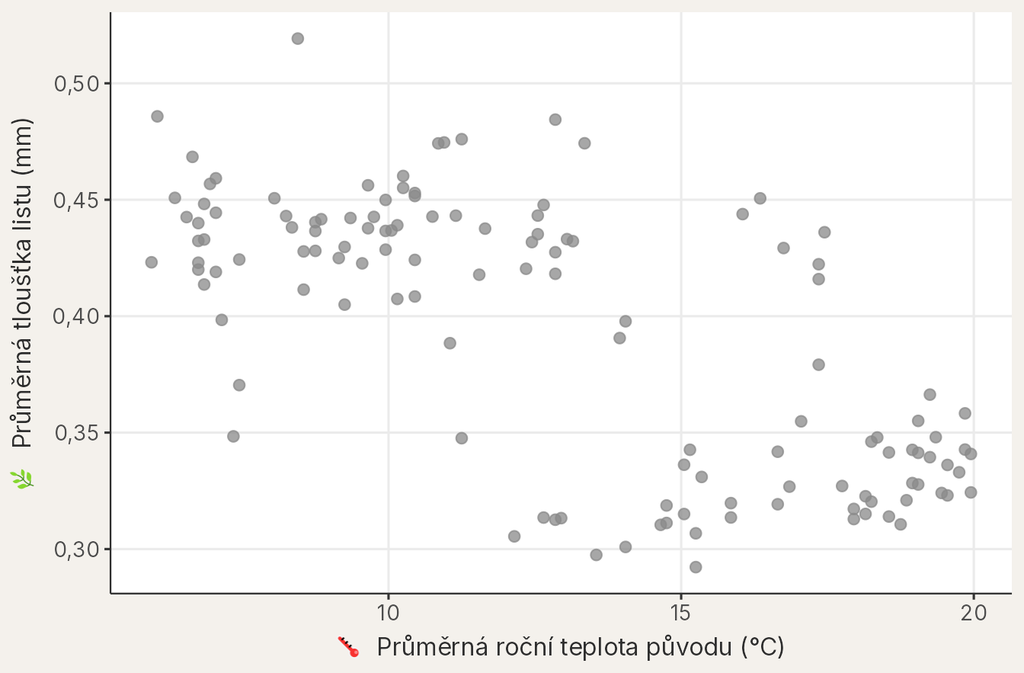

Průměrná tloušťka listu a průměrná roční teplota místa původu. Jeden bod je jedna populace pěstovaná v Šanghaji.

**QuestionCo dokážeme vyčíst z grafu?**

Popište směr a těsnost vztahu. Jak těsně body sledují klesající směr a vidíte neobvyklá pozorováníJeden zaznamenaný případ v datech, který obsahuje hodnoty jedné nebo více proměnných.?

**DůležitéMožná odpověď**

Body převážně klesají: populace z teplejších míst mají v průměru tenčí listy. Vztah je zřetelný, ale body neleží na přímce; při stejné teplotě se tloušťka populací liší. Žádný bod nestojí úplně mimo ostatní, i když několik populací leží výrazněji nad nebo pod hlavním mrakem.

Z předchozích lekcí známe korelaciBezrozměrné číslo popisující směr a těsnost vztahu dvou proměnných; Pearsonova korelace shrnuje lineární vztah a Spearmanova monotónní vztah podle pořadí., která směr a těsnost takového vztahu shrne jedním číslem:

```r
# Pearsonova korelace roční teploty a tloušťky listu
cor(
  x = data_kridlatka$teplota_rocni_C,
  y = data_kridlatka$tloustka_listu_mm
)
```

```
[1] -0.6931225
```

Záporná hodnota −0,69 potvrzuje klesající a poměrně těsný vztah. Korelace však nemá jednotky; neřekne nám, o kolik milimetrů se tloušťka listu liší při rozdílu teploty 1 °C. K tomu použijeme známý lineární modelStatistický model, v němž je průměrná odezva součtem interceptu a prediktorů násobených koeficienty; lineární je v koeficientech, takže nemusí jít jen o přímku..

## 5 Jedna teplota, jeden sklon

Model s průměrnou roční teplotou jako jediným prediktoremProměnná, pomocí níž vysvětlujeme variabilitu odezvy; v notaci y ~ x je prediktor x. fitujeme stejně jako v předchozích lekcích:

```r
# Fitujeme přímku s jedinou klimatickou proměnnou
mod_rocni_teplota <-
  lm(
    formula = tloustka_listu_mm ~ teplota_rocni_C,
    data = data_kridlatka
  )

# Zobrazíme celý přehled modelu
summary(object = mod_rocni_teplota)
```

```
Call:
lm(formula = tloustka_listu_mm ~ teplota_rocni_C, data = data_kridlatka)

Residuals:
      Min        1Q    Median        3Q       Max
-0.095017 -0.026242  0.003225  0.025530  0.091216

Coefficients:
                  Estimate Std. Error t value Pr(>|t|)
(Intercept)      0.5105454  0.0115134   44.34   <2e-16 ***
teplota_rocni_C -0.0091332  0.0008462  -10.79   <2e-16 ***
---
Signif. codes:  0 '***' 0.001 '**' 0.01 '*' 0.05 '.' 0.1 ' ' 1

Residual standard error: 0.04161 on 126 degrees of freedom
Multiple R-squared:  0.4804,    Adjusted R-squared:  0.4763
F-statistic: 116.5 on 1 and 126 DF,  p-value: < 2.2e-16
```

**QuestionCo už umíme přečíst z výstupu?**

Najděte ve výstupu řádek `teplota_rocni_C` a odpovězte:

1. Jaké znaménko má odhadČíslo vypočtené z pozorovaných dat jako přiblížení neznámé vlastnosti nebo parametru; jiný srovnatelný výběr může dát jiný odhad. koeficientu?
2. V jakých jednotkách koeficient interpretujeme?
3. Jakou změnu tloušťky model očekává při rozdílu 5 °C?

**DůležitéMožná odpověď**

Koeficient je záporný, −0,00913 mm na 1 °C. Dvě populace, jejichž místa původu se liší průměrnou roční teplotou o 1 °C, se podle modelu liší v tloušťce listu v průměru o 0,00913 mm; teplejší populace má tenčí list. Výpočet pro rozdíl 5 °C ukazuje následující odstavec.

Odhadnutý rozdíl tloušťky dvou populací získáme vynásobením sklonuParametr lineárního modelu udávající, o kolik se v průměru liší odezva dvou pozorování, jejichž prediktor se liší o jednu jednotku (při stejných hodnotách ostatních prediktorů). rozdílem jejich teplot:

$$\text{odhadnutý rozdíl tloušťky} = \text{sklon roční teploty} \times \text{rozdíl roční teploty}.$$

Pro rozdíl 5 °C to je

$$-0{,}00913 \times 5
= -0{,}046\ \mathrm{mm}.$$

Populace z místa teplejšího o 5 °C má tedy podle modelu v průměru list tenčí asi o 0,046 mm. Přímka v grafu ukazuje odhadnutou tloušťku pro jednotlivé roční teploty a fialový pás spolehlivostiPás kolem odhadnuté přímky, který pro každou hodnotu prediktoru ukazuje interval spolehlivosti pro průměrnou hodnotu odezvy; neukazuje, kde leží 95 % pozorování. nejistotuRozsah, v němž nevíme přesnou hodnotu parametru kvůli omezenému výběru a výběrové variabilitě; kvantifikuje se pomocí standardních chyb a intervalů spolehlivosti. průměrného trenduPrůměrná hodnota odezvy, kterou model odhaduje pro danou hodnotu prediktoru; graficky výška odhadnuté přímky.:

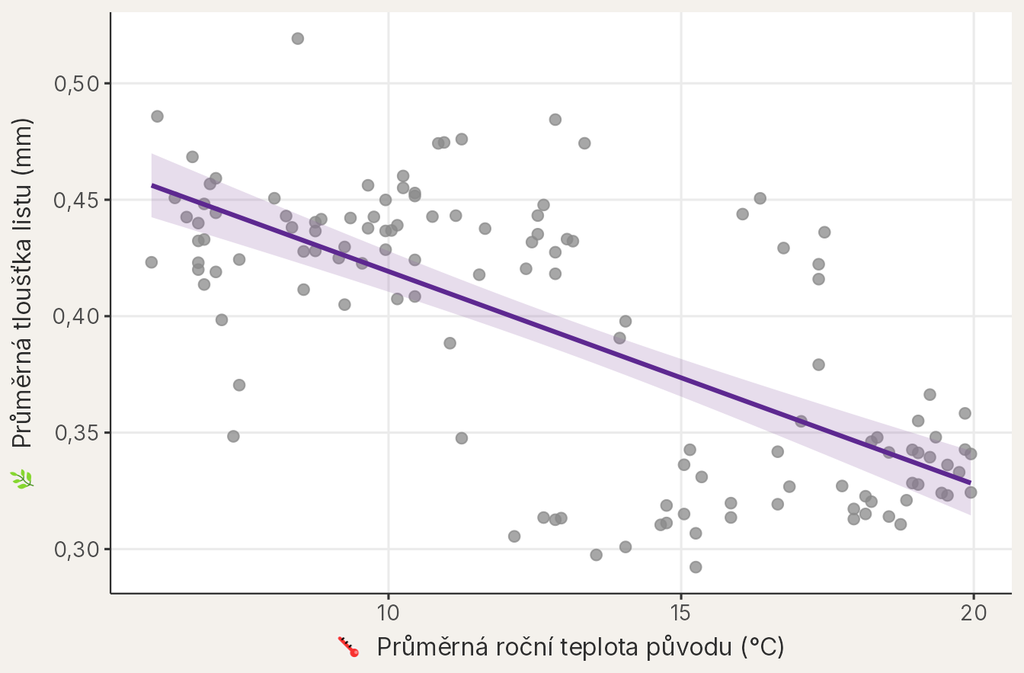

Pozorované populace a trend odhadnutý modelem s průměrnou roční teplotou.

**TipDoplňující: údaj o popsané variabilitě**

Ve výstupu `summary()` je také R²Podíl variability odezvy zachycený modelem: R² = 1 − RSS / celkový součet čtverců (0 = model nezachytí nic navíc oproti průměru, 1 = zachytí vše). = 0,480. Tato hodnota říká, že přímka s roční teplotou popisuje přibližně 48 % variabilityObecný termín pro rozsah, v němž se hodnoty proměnné liší od sebe navzájem; kvantifikuje se pomocí rozptylu, SD, IQR nebo rozsahu. populačních průměrů tloušťky. R² samo nerozhoduje, který z několika modelů máme upřednostnit; jeho využití při porovnávání modelů patří do pozdější lekce.

### 5.1 Sedí přímka k datům?

Po interpretaci koeficientu zkontrolujeme residuaRozdíl mezi pozorovanou hodnotou odezvy a hodnotou odhadnutou modelem: eᵢ = yᵢ − ŷᵢ.: rozdíly mezi pozorovanou tloušťkou a hodnotou na přímce. Vykreslíme je proti hodnotám odhadnutým modelemHodnota odezvy, kterou fitovaný model přiřadí pozorování na základě jeho hodnot prediktorů; značí se často ŷ.:

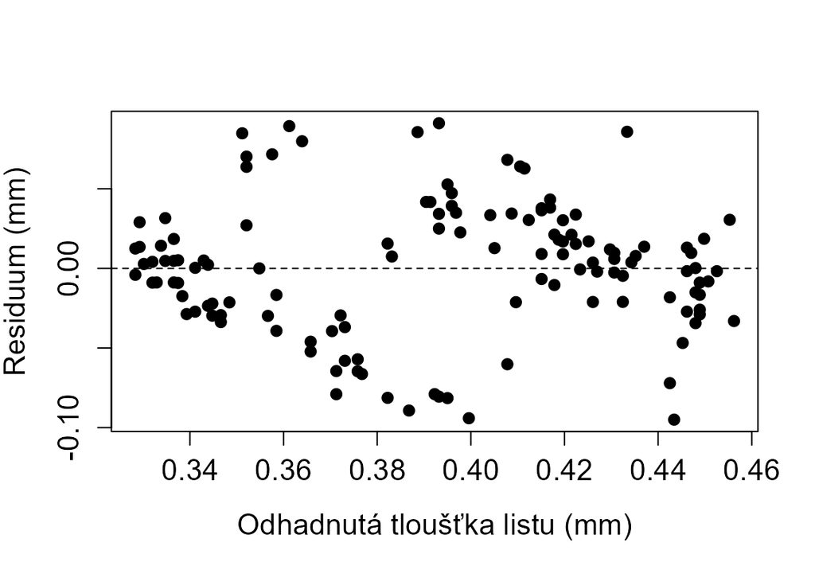

```r
# Z modelu získáme residua a odhadnuté hodnoty
vec_residua_rocni <- resid(object = mod_rocni_teplota)
vec_odhad_rocni <- fitted(object = mod_rocni_teplota)

# Residua proti odhadnutým hodnotám s přerušovanou čarou v nule
plot(
  x = vec_odhad_rocni,
  y = vec_residua_rocni,
  xlab = "Odhadnutá tloušťka listu (mm)",
  ylab = "Residuum (mm)",
  pch = 16,
  cex = 1.2,
  cex.axis = 1.3,
  cex.lab = 1.3
)
abline(h = 0, lty = 2)
```

Body by měly být rozptýlené kolem vodorovné nuly bez nápadného oblouku nebo vějíře. Oblouk ani vějíř zde nevidíme, takže přímka je pro hrubý popis vztahu přijatelná. Body ale nejsou rozmístěné úplně náhodně: při nízkých až středních odhadnutých hodnotách leží spíš pod nulou, potom spíš nad ní. Přímka tedy něco nezachytila. Residua jsou navíc poměrně velká: roční teplota zdaleka nevysvětluje všechny rozdíly mezi populacemi. Co v residuích zůstalo, ukáže část o původu populací.

## 6 Také nejteplejší měsíc souvisí s tloušťkou listu

V tabulce máme také maximum teploty nejteplejšího měsíce. Stejným postupem ověříme, jak souvisí s tloušťkou listu samo o sobě:

```r
# Fitujeme přímku s maximem nejteplejšího měsíce
mod_max_teplota <-
  lm(
    formula = tloustka_listu_mm ~ teplota_max_C,
    data = data_kridlatka
  )

# Zobrazíme celý přehled modelu
summary(object = mod_max_teplota)
```

```
Call:
lm(formula = tloustka_listu_mm ~ teplota_max_C, data = data_kridlatka)

Residuals:
      Min        1Q    Median        3Q       Max
-0.087708 -0.026667 -0.007747  0.029279  0.119924

Coefficients:
                Estimate Std. Error t value Pr(>|t|)
(Intercept)    0.6509898  0.0247701   26.28   <2e-16 ***
teplota_max_C -0.0095029  0.0009013  -10.54   <2e-16 ***
---
Signif. codes:  0 '***' 0.001 '**' 0.01 '*' 0.05 '.' 0.1 ' ' 1

Residual standard error: 0.04207 on 126 degrees of freedom
Multiple R-squared:  0.4687,    Adjusted R-squared:  0.4645
F-statistic: 111.2 on 1 and 126 DF,  p-value: < 2.2e-16
```

Model odhaduje rozdíl −0,00950 mm při maximu nejteplejšího měsíce vyšším o 1 °C. Také tento sklonParametr lineárního modelu udávající, o kolik se v průměru liší odezva dvou pozorování, jejichž prediktor se liší o jednu jednotku (při stejných hodnotách ostatních prediktorů). popisuje celkový vztah k jedné části teplotního režimu, bez ohledu na ostatní klimatické vlastnosti.

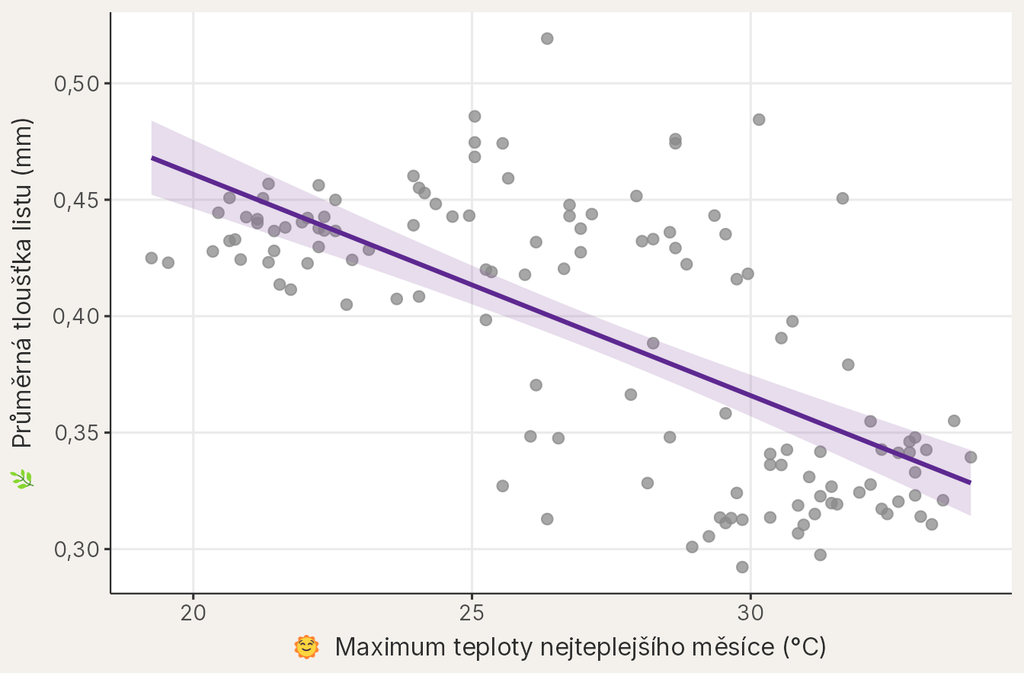

Pozorované populace a trend odhadnutý modelem s maximem teploty nejteplejšího měsíce.

Také u tohoto modelu zkontrolujeme residuaRozdíl mezi pozorovanou hodnotou odezvy a hodnotou odhadnutou modelem: eᵢ = yᵢ − ŷᵢ. stejným grafem:

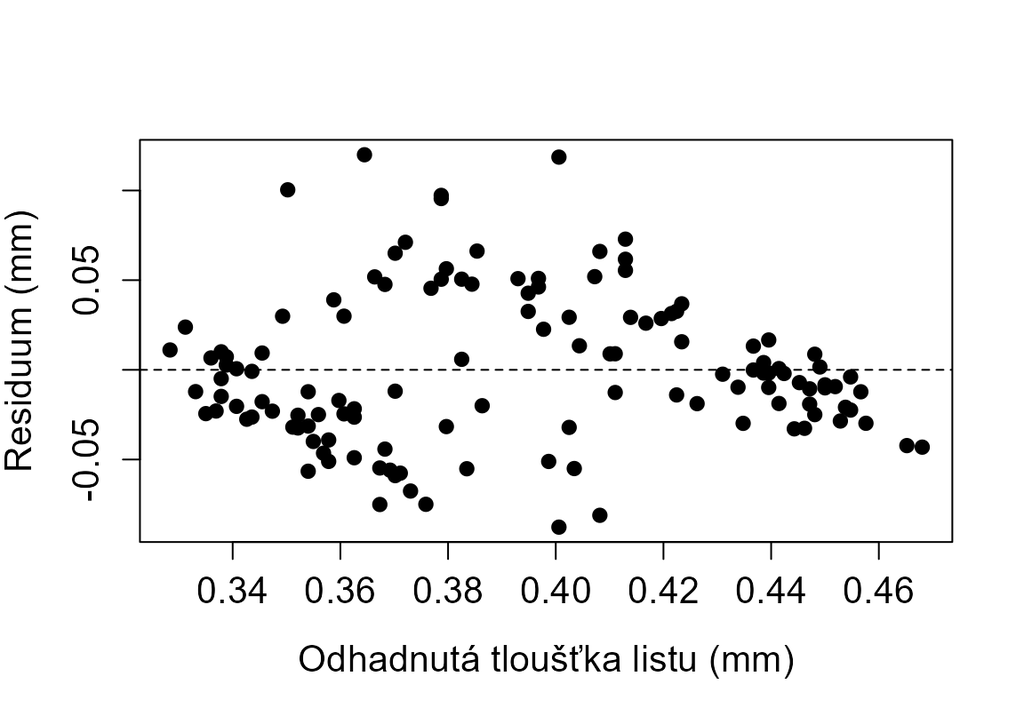

```r
# Residua proti odhadnutým hodnotám modelu s maximem
plot(
  x = fitted(object = mod_max_teplota),
  y = resid(object = mod_max_teplota),
  xlab = "Odhadnutá tloušťka listu (mm)",
  ylab = "Residuum (mm)",
  pch = 16,
  cex = 1.2,
  cex.axis = 1.3,
  cex.lab = 1.3
)
abline(h = 0, lty = 2)
```

Residua jsou rozptýlená kolem nuly bez výrazného oblouku nebo vějíře. Oba jednoduché modely tedy ukazují klesající klimatický trend. Každý z nich ale používá jen jednu část teplotního režimu a kolem přímky zůstává značná variabilitaObecný termín pro rozsah, v němž se hodnoty proměnné liší od sebe navzájem; kvantifikuje se pomocí rozptylu, SD, IQR nebo rozsahu..

## 7 Jeden model, dvě teploty

Chceme odhadovat tloušťku listu podle průměrné roční i maximální teploty současně. Do formule přidáme druhý prediktorProměnná, pomocí níž vysvětlujeme variabilitu odezvy; v notaci y ~ x je prediktor x. znaménkem `+`:

```r
# Jeden model se dvěma teplotními prediktory
mod_dve_teploty <-
  lm(
    formula = tloustka_listu_mm ~ teplota_rocni_C + teplota_max_C,
    data = data_kridlatka
  )

# Zobrazíme celý přehled modelu
summary(object = mod_dve_teploty)
```

```
Call:
lm(formula = tloustka_listu_mm ~ teplota_rocni_C + teplota_max_C,
    data = data_kridlatka)

Residuals:
      Min        1Q    Median        3Q       Max
-0.081384 -0.024798 -0.003083  0.025821  0.105537

Coefficients:
                 Estimate Std. Error t value Pr(>|t|)
(Intercept)      0.589936   0.030071  19.618  < 2e-16 ***
teplota_rocni_C -0.005279   0.001585  -3.330  0.00114 **
teplota_max_C   -0.004751   0.001670  -2.845  0.00519 **
---
Signif. codes:  0 '***' 0.001 '**' 0.01 '*' 0.05 '.' 0.1 ' ' 1

Residual standard error: 0.04048 on 125 degrees of freedom
Multiple R-squared:  0.512, Adjusted R-squared:  0.5042
F-statistic: 65.58 on 2 and 125 DF,  p-value: < 2.2e-16
```

Znaménko `+` ve formuli říká, že model odhaduje příspěvek **obou prediktorů současně**. Neznamená, že se dvě naměřené teploty prostě sečtou. Koeficient roční teploty popisuje její vztah k tloušťce **při stejném maximu nejteplejšího měsíce**; koeficient maxima popisuje jeho vztah **při stejné roční teplotě**. Takovému modelu, ve kterém se příspěvky prediktorů jen sčítají, říkáme **aditivní modelModel s více prediktory bez interakce: příspěvky prediktorů se sčítají, takže vztah odezvy k jednomu prediktoru je stejný při všech hodnotách ostatních.**.

**QuestionKteré tři parametry model odhadl?**

Ve výstupu `summary()` najděte tři parametry modeluČíselné hodnoty odhadnuté z dat definující tvar modelu; v lineárním modelu jsou to intercept a sklon(y).. Jak byste každý z nich popsali jednou větou a v jakých jednotkách?

**DůležitéMožná odpověď**

Řádek `(Intercept)` je interceptParametr modelu: odhadnutá hodnota odezvy, když jsou všechny numerické prediktory rovny nule a kategoriální prediktory jsou v referenční skupině; geometricky jde o úsek na ose y., 0,590 mm: odhadnutá tloušťka při nulové roční i nulové maximální teplotě. Taková kombinace v datech není, takže intercept slouží hlavně jako výchozí bod rovnice. Koeficient `teplota_rocni_C`, −0,00528 mm na 1 °C, porovnává populace se stejným maximem nejteplejšího měsíce, které se liší roční teplotou. Koeficient `teplota_max_C`, −0,00475 mm na 1 °C, porovnává populace se stejnou roční teplotou, které se liší maximem nejteplejšího měsíce.

Slovně model skládá odhadnutou hodnotuHodnota odezvy, kterou fitovaný model přiřadí pozorování na základě jeho hodnot prediktorů; značí se často ŷ. ze tří částí:

$$\begin{aligned}
\text{odhadnutá tloušťka listu} ={}& \text{intercept} \\
&+ \text{sklon roční teploty} \times \text{roční teplota} \\
&+ \text{sklon maxima} \times \text{maximum nejteplejšího měsíce}.
\end{aligned}$$

Konkrétní dosazení ukážeme na jedné skutečné populaci:

```r
# Vybereme populaci CN35 a její dvě teploty
data_priklad <-
  data_kridlatka[
    data_kridlatka$populace == "CN35",
    c("populace", "teplota_rocni_C", "teplota_max_C")
  ]

data_priklad
```

```
   populace teplota_rocni_C teplota_max_C
29     CN35           15.25         29.85
```

Populace CN35 pochází z místa s průměrnou roční teplotou 15,25 °C a maximem nejteplejšího měsíce 29,85 °C. Dosazení odhadnutých parametrů a těchto teplot je

$$\begin{aligned}
\widehat{\text{tloušťka}} &=
0{,}5899
+ (-0{,}00528)
\times 15{,}25 \\
&\quad + (-0{,}00475)
\times 29{,}85 \\
&= 0{,}5899
-0{,}0805
-0{,}1418 \\
&= 0{,}368\ \mathrm{mm}.
\end{aligned}$$

Stejnou strukturu zapisujeme pro dva prediktory obecně jako

$$y_i = \beta_0 + \beta_1 x_{1i} + \beta_2 x_{2i} + \varepsilon_i,$$

a pro $p$ prediktorů jako

$$y_i = \beta_0 + \sum_{j=1}^{p}\beta_j x_{ji} + \varepsilon_i.$$

$y_i$ je tloušťka listu populace $i$; $\beta_0$ je intercept; $\beta_j$ je koeficient prediktoru $j$; $x_{ji}$ je hodnota prediktoru $j$ u populace $i$; $p$ je počet prediktorů; $j$ označuje konkrétní prediktor a $\varepsilon_i$ odchylku populace od modelu. Každý koeficient má **podmíněný význam**: $\beta_1$ porovnává populace lišící se v $x_1$ při stejných hodnotách ostatních prediktorů.

## 8 Klimatické proměnné nenesou nezávislé informace

Osm klimatických proměnných v tabulce popisuje různé části stejného klimatu. Proto se vyplatí podívat se na vztahy mezi samotnými prediktoryProměnná, pomocí níž vysvětlujeme variabilitu odezvy; v notaci y ~ x je prediktor x..

**QuestionKteré dvojice budou silně souviset?**

Než se podíváte na následující obrázek, vyberte dvě klimatické proměnné, u nichž očekáváte silnou kladnou korelaciBezrozměrné číslo popisující směr a těsnost vztahu dvou proměnných; Pearsonova korelace shrnuje lineární vztah a Spearmanova monotónní vztah podle pořadí.. Který biologický nebo fyzikální vztah váš odhad podporuje?

**DůležitéMožná odpověď**

Silně kladně by měly souviset například průměrná roční teplota a maximum nejteplejšího měsíce: obě popisují, jak teplé místo je. Podobně spolu budou souviset roční srážky a srážky nejvlhčího měsíce, protože nejvlhčí měsíc tvoří velkou část ročního úhrnu.

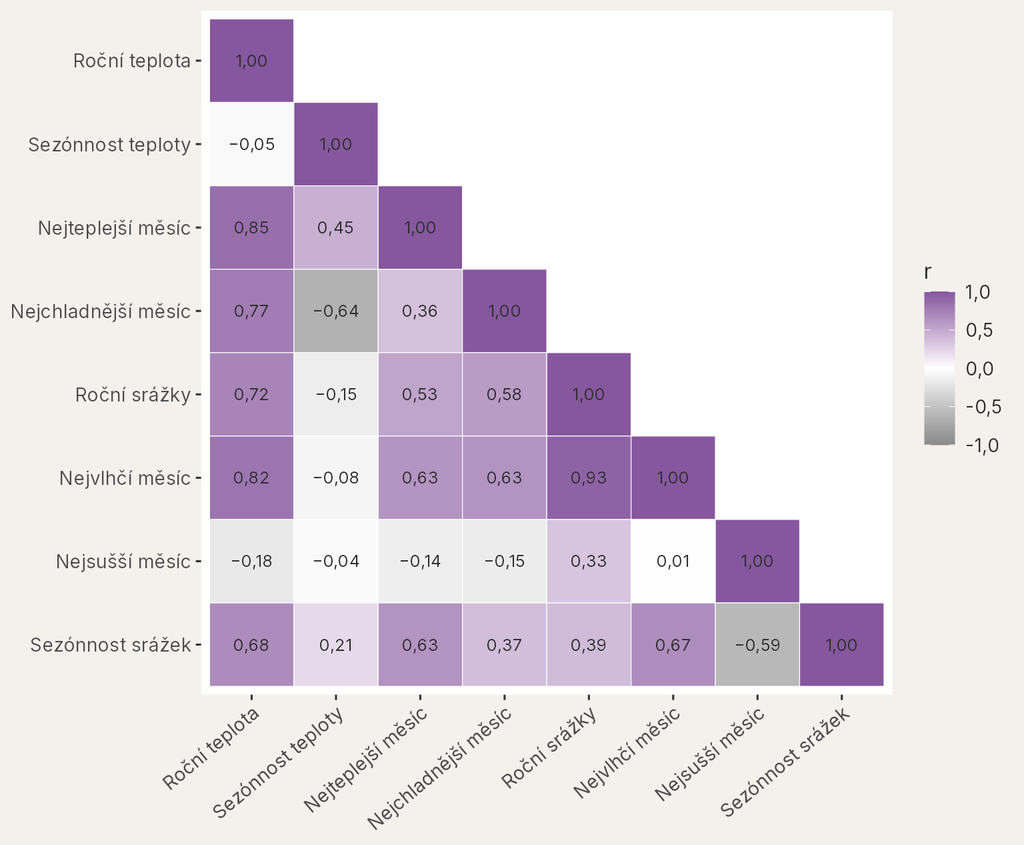

Korelační matice osmi klimatických proměnných. Čísla jsou Pearsonovy korelační koeficienty; fialová značí kladnou, šedá zápornou korelaci.

**TipDoplňující: jak korelační matici spočítat**

Matici spočítáme funkcí `cor()`, které předáme tabulku jen s číselnými klimatickými sloupci. Výsledkem je čtvercová tabulka: v řádku i sloupci jsou stejné proměnné a každá buňka obsahuje korelaci jedné dvojice. Graf výše zobrazuje stejná čísla barevně a každou dvojici jen jednou.

```r
# Vybereme osm číselných klimatických sloupců
vec_klima <-
  c(
    "teplota_rocni_C", "teplota_sezonnost", "teplota_max_C",
    "teplota_min_C", "srazky_rocni_mm", "srazky_nejvlhci_mesic_mm",
    "srazky_nejsussi_mesic_mm", "srazky_sezonnost"
  )

# Korelace všech dvojic, zaokrouhlené na dvě desetinná místa
round(
  x = cor(x = data_kridlatka[, vec_klima]),
  digits = 2
)
```

```
                         teplota_rocni_C teplota_sezonnost teplota_max_C
teplota_rocni_C                     1.00             -0.05          0.85
teplota_sezonnost                  -0.05              1.00          0.45
teplota_max_C                       0.85              0.45          1.00
teplota_min_C                       0.77             -0.64          0.36
srazky_rocni_mm                     0.72             -0.15          0.53
srazky_nejvlhci_mesic_mm            0.82             -0.08          0.63
srazky_nejsussi_mesic_mm           -0.18             -0.04         -0.14
srazky_sezonnost                    0.68              0.21          0.63
                         teplota_min_C srazky_rocni_mm srazky_nejvlhci_mesic_mm
teplota_rocni_C                   0.77            0.72                     0.82
teplota_sezonnost                -0.64           -0.15                    -0.08
teplota_max_C                     0.36            0.53                     0.63
teplota_min_C                     1.00            0.58                     0.63
srazky_rocni_mm                   0.58            1.00                     0.93
srazky_nejvlhci_mesic_mm          0.63            0.93                     1.00
srazky_nejsussi_mesic_mm         -0.15            0.33                     0.01
srazky_sezonnost                  0.37            0.39                     0.67
                         srazky_nejsussi_mesic_mm srazky_sezonnost
teplota_rocni_C                             -0.18             0.68
teplota_sezonnost                           -0.04             0.21
teplota_max_C                               -0.14             0.63
teplota_min_C                               -0.15             0.37
srazky_rocni_mm                              0.33             0.39
srazky_nejvlhci_mesic_mm                     0.01             0.67
srazky_nejsussi_mesic_mm                     1.00            -0.59
srazky_sezonnost                            -0.59             1.00
```

Průměrná roční teplota a maximum nejteplejšího měsíce korelují 0,855. Obě proměnné proto nesou z velké části stejnou informaci o tom, jak teplé je místo původu:

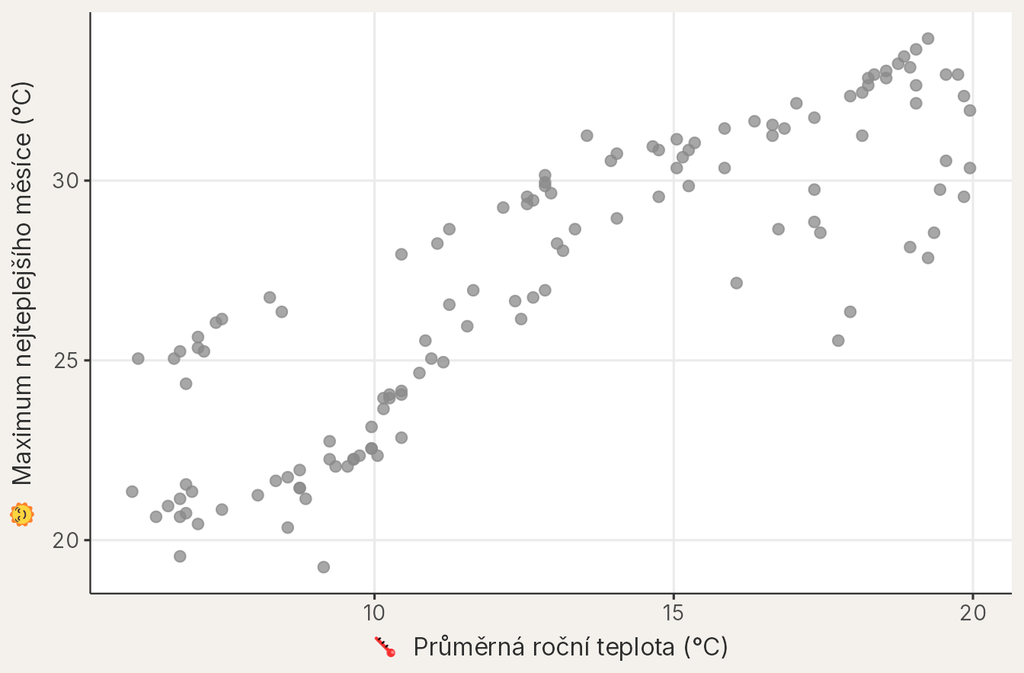

Průměrná roční teplota a maximum nejteplejšího měsíce místa původu. Jeden bod je jedna populace.

Když prediktory v modelu spolu silně souvisejí, mluvíme o korelaci prediktorůSituace, kdy dva nebo více prediktorů v modelu navzájem korelují; silná korelace způsobuje nestabilitu odhadů.. Co to znamená pro model, uvidíme v následující části.

## 9 Proč se odhad roční teploty změnil?

Porovnáme koeficient roční teploty v modelu, kde je jediným prediktoremProměnná, pomocí níž vysvětlujeme variabilitu odezvy; v notaci y ~ x je prediktor x., a v modelu se dvěma teplotami. Oba modely používají stejných 128 populací, takže rozdíl nevzniká změnou analyzovaných řádků.

```r
# Celá tabulka koeficientů modelu s jednou teplotou
coef(object = summary(object = mod_rocni_teplota))
```

```
                    Estimate Std. Error   t value     Pr(>|t|)
(Intercept)      0.510545418 0.01151336  44.34376 9.711812e-79
teplota_rocni_C -0.009133159 0.00084616 -10.79365 1.237814e-19
```

```r
# Celá tabulka koeficientů modelu se dvěma teplotami
coef(object = summary(object = mod_dve_teploty))
```

```
                    Estimate  Std. Error   t value     Pr(>|t|)
(Intercept)      0.589935700 0.030071033 19.618073 5.666443e-40
teplota_rocni_C -0.005278927 0.001585346 -3.329828 1.142457e-03
teplota_max_C   -0.004750850 0.001669974 -2.844864 5.193218e-03
```

V každé tabulce najdeme řádek `teplota_rocni_C`. Sloupec `Estimate` obsahuje odhadČíslo vypočtené z pozorovaných dat jako přiblížení neznámé vlastnosti nebo parametru; jiný srovnatelný výběr může dát jiný odhad. koeficientu a sloupec `Std. Error` jeho standardní chybuMíra přesnosti odhadu parametru (průměru, sklonu…); odhaduje z jediného výběru, jak moc by se odhady typicky lišily mezi opakovanými výběry stejné velikosti..

Odhad se změní z −0,00913 na −0,00528 mm na 1 °C. V prvním modelu koeficient roční teploty zahrnuje veškerou informaci, kterou tato proměnná nese o celkovém teplotním režimu, včetně té, kterou sdílí s maximem nejteplejšího měsíce. Po přidání maxima se ptáme na užší otázku: jak se liší tloušťka listu mezi populacemi se **stejným maximem**, ale odlišnou průměrnou roční teplotou.

Standardní chyba současně vzroste z 0,00085 na 0,00159 mm na 1 °C. Proč přesnost klesla, napoví graf dvou teplot z předchozí části.

**QuestionJakou otázku zodpovídá koeficient roční teploty?**

Koeficient roční teploty v modelu se dvěma teplotami porovnává populace se stejným maximem nejteplejšího měsíce, které se liší průměrnou roční teplotou. Najděte v předchozím bodovém grafuGraf vztahu dvou numerických proměnných, v němž každý bod představuje jedno pozorování a jeho dvě hodnoty určují polohu na osách. dvou teplot populace, které takové srovnání skutečně umožňují. Je jich hodně, nebo málo?

**DůležitéMožná odpověď**

Hledáme body, které leží na téměř stejné výšce (stejné maximum), ale daleko od sebe ve vodorovném směru (různá roční teplota). Protože body tvoří úzký rostoucí mrak, je takových dvojic málo a leží hlavně na okrajích mraku.

Na podmíněnou otázku proto odpovídá jen malá část dat. Model o ní ví méně než o celkovém vztahu, a samostatné příspěvky obou teplot se tak oddělují s větší nejistotouRozsah, v němž nevíme přesnou hodnotu parametru kvůli omezenému výběru a výběrové variabilitě; kvantifikuje se pomocí standardních chyb a intervalů spolehlivosti., přestože model lze bez problému fitovat.

**TipDoplňující: korelované prediktory mohou vytvářet nestabilní koeficienty**

Když dva prediktory nesou téměř stejnou informaci, model má málo pozorování, která by je dokázala od sebe oddělit. Malá změna dat nebo přidání několika populací pak může výrazně změnit jejich jednotlivé koeficienty, znaménka i standardní chyby. Proto je nečteme jako dvě samostatné biologické odpovědi bez ohledu na jejich překryv.

Pomocným ukazatelem bývá VIFUkazatel, nakolik je rozptyl (nejistota) odhadu koeficientu zvětšen tím, že prediktor koreluje s ostatními prediktory v modelu. (*variance inflation factor*), který shrnuje, nakolik je nejistota koeficientu zvětšena překryvem s ostatními prediktory. VIF ale nemá univerzální hranici, po jejímž překročení musíme proměnnou automaticky smazat. Rozhodujeme podle biologické otázky, rozsahu společně pozorovaných hodnot a toho, zda chceme samostatně interpretovat koeficienty, nebo predikovatHodnota odezvy, kterou model odhaduje pro nové pozorování nebo pro zvolenou kombinaci prediktorů, která nebyla mezi daty použitými k odhadu modelu. podporované kombinace.

**TipDoplňující: porovnání není výběr nejlepšího modelu**

Zde porovnáváme koeficienty, protože chceme pochopit, jak přidání souvisejícího prediktoru změnilo statistickou otázku. O výběru modelu ale nerozhodujeme. V dalších lekcích budeme pracovat s principem úspornostiZásada, že ze dvou modelů, které popisují data podobně dobře, dáváme přednost jednoduššímu.: mezi biologicky smysluplnými modely budeme hledat takový, který popisuje data dostatečně dobře bez zbytečné složitosti. K tomu nestačí vybrat model s nejvyšším R²Podíl variability odezvy zachycený modelem: R² = 1 − RSS / celkový součet čtverců (0 = model nezachytí nic navíc oproti průměru, 1 = zachytí vše)..

### 9.1 Změnil druhý prediktor strukturu residuí?

Také model se dvěma teplotami zkontrolujeme grafem residuíRozdíl mezi pozorovanou hodnotou odezvy a hodnotou odhadnutou modelem: eᵢ = yᵢ − ŷᵢ.:

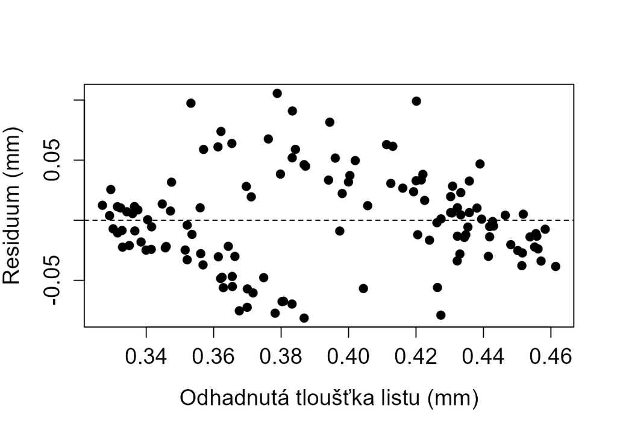

```r
# Residua proti odhadnutým hodnotám modelu se dvěma teplotami
plot(
  x = fitted(object = mod_dve_teploty),
  y = resid(object = mod_dve_teploty),
  xlab = "Odhadnutá tloušťka listu (mm)",
  ylab = "Residuum (mm)",
  pch = 16,
  cex = 1.2,
  cex.axis = 1.3,
  cex.lab = 1.3
)
abline(h = 0, lty = 2)
```

Graf vypadá podobně jako u modelu s jednou teplotou: žádný výrazný oblouk ani vějíř, ale stejné mírné seskupení residuí pod nulou a nad ní. Druhá teplota je tedy nevysvětlila. Změnu koeficientu proto nečteme jako opravu nevyhovujícího prvního modelu, ale jako změnu otázky a její nejistoty.

## 10 Původ populací mění příběh vztahu

Jeden lineární modelStatistický model, v němž je průměrná odezva součtem interceptu a prediktorů násobených koeficienty; lineární je v koeficientech, takže nemusí jít jen o přímku. může kombinovat numerické i kategoriální prediktoryProměnná, pomocí níž vysvětlujeme variabilitu odezvy; v notaci y ~ x je prediktor x.. Typ prediktoru nemění základní princip: znaménkem `+` přidáváme do stejného modelu další informaci. Rozlišíme pozorované populace podle původu, zatím bez modelových přímek:

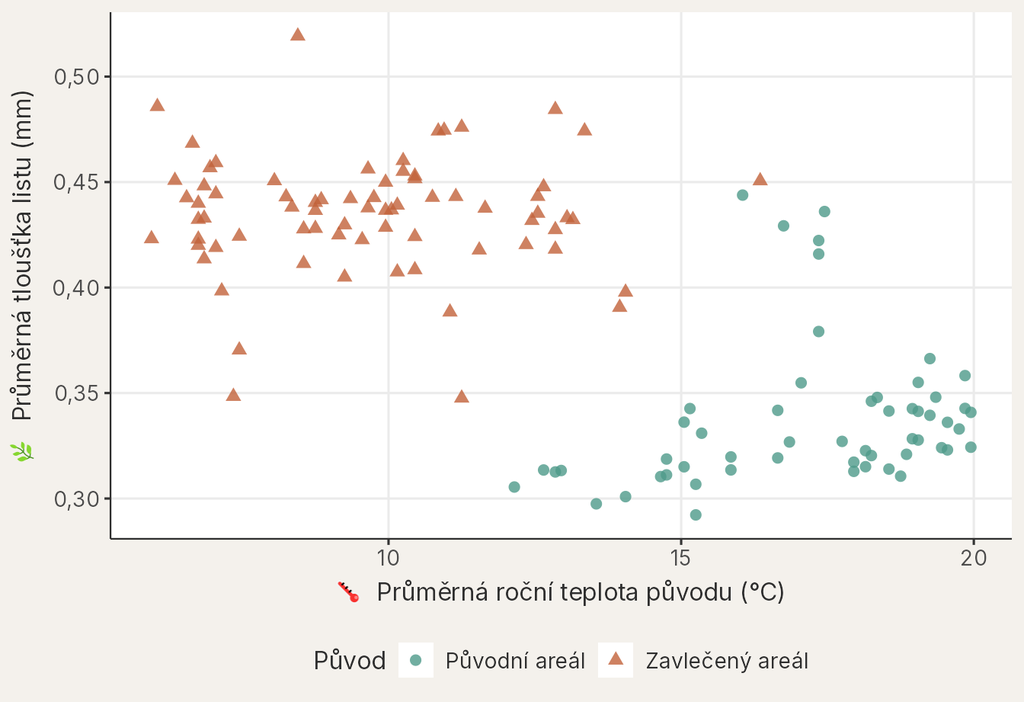

Pozorované populace rozlišené podle původního a zavlečeného areálu. Jeden bod je jedna zdrojová populace.

**QuestionJak se liší obě skupiny?**

Ve kterých teplotách pozorujeme původní a zavlečené populace? Která skupina má při podobné teplotě výše položené body? Je klesající vztah stejně zřetelný uvnitř obou skupin jako v celém souboru?

**DůležitéMožná odpověď**

Původní populace pocházejí převážně z teplejších míst, zavlečené z chladnějších. Tam, kde se teploty obou skupin překrývají, leží zavlečené populace výše: mají silnější listy. Uvnitř každé skupiny už klesající vztah zřetelný není. Velká část celkového poklesu tak vzniká tím, že skupiny leží v různých částech teplotní osy.

Celkový vztah napříč všemi populacemi proto spojuje dvě věci: rozdíl mezi skupinami a případný vztah k teplotě uvnitř skupin. K roční teplotě přidáme kategoriální prediktor původu:

```r
# Jeden model s původem a roční teplotou
mod_puvod <-
  lm(
    formula = tloustka_listu_mm ~ puvod + teplota_rocni_C,
    data = data_kridlatka
  )

# Zobrazíme celý přehled modelu
summary(object = mod_puvod)
```

```
Call:
lm(formula = tloustka_listu_mm ~ puvod + teplota_rocni_C, data = data_kridlatka)

Residuals:
      Min        1Q    Median        3Q       Max
-0.089547 -0.017475 -0.003619  0.009723  0.108468

Coefficients:
                Estimate Std. Error t value Pr(>|t|)
(Intercept)     0.311427   0.021253  14.653   <2e-16 ***
puvodZavleceny  0.108947   0.010651  10.228   <2e-16 ***
teplota_rocni_C 0.001491   0.001213   1.229    0.221
---
Signif. codes:  0 '***' 0.001 '**' 0.01 '*' 0.05 '.' 0.1 ' ' 1

Residual standard error: 0.03082 on 125 degrees of freedom
Multiple R-squared:  0.7172,    Adjusted R-squared:  0.7126
F-statistic: 158.5 on 2 and 125 DF,  p-value: < 2.2e-16
```

**QuestionJak číst model s teplotou a původem?**

Která skupina je ve výstupu referenční? Najděte společný sklonParametr lineárního modelu udávající, o kolik se v průměru liší odezva dvou pozorování, jejichž prediktor se liší o jednu jednotku (při stejných hodnotách ostatních prediktorů). roční teploty a posun zavlečených populací vůči původním. Jak byste oba koeficienty popsali v biologických jednotkách?

**DůležitéMožná odpověď**

Referenční skupinouÚroveň kategoriálního prediktoru, vůči které model vyjadřuje rozdíly ostatních skupin; její průměr (při nulových numerických prediktorech) je intercept. jsou původní populace, protože ve výstupu je jen řádek `puvodZavleceny`. Jeho koeficient, 0,109 mm, říká, o kolik silnější list mají zavlečené populace než původní **při stejné roční teplotě**. Koeficient `teplota_rocni_C`, +0,00149 mm na 1 °C, je sklon roční teploty **při stejném původu**; model předpokládá, že je v obou skupinách stejný.

Model se znaménkem `+` je i zde aditivní. Koeficient původu posouvá jednu skupinu vůči druhé, zatímco koeficient roční teploty určuje společný sklon obou skupin. V grafu proto vidíme dvě rovnoběžné přímky. Každou kreslíme jen v rozsahu teplot, ve kterém danou skupinu skutečně pozorujeme:

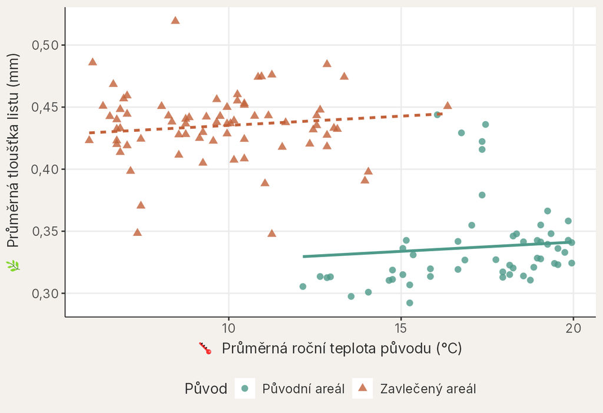

Body jsou pozorované populace. Rovnoběžné přímky jsou odhady aditivního modelu se společným sklonem roční teploty a rozdílnou výškou pro každý původ; každá přímka pokrývá jen pozorované teploty své skupiny.

Přímky jsou téměř vodorovné. Rozdíl mezi nimi, tedy posun zavlečených populací, je zato zřetelný.

**TipDoplňující: co kdyby skupiny neměly společný sklon?**

Graf může vyvolat otázku, zda se vztah mezi roční teplotou a tloušťkou listu liší podle původu populace. Takovou otázku řeší interakce prediktorůSituace, kdy efekt jednoho prediktoru na odezvu závisí na hodnotě jiného prediktoru.: dovolila by každé skupině jiný sklon, takže přímky by nemusely být rovnoběžné. Interakce patří do následující lekce; zde ji nefitujeme ani neinterpretujeme.

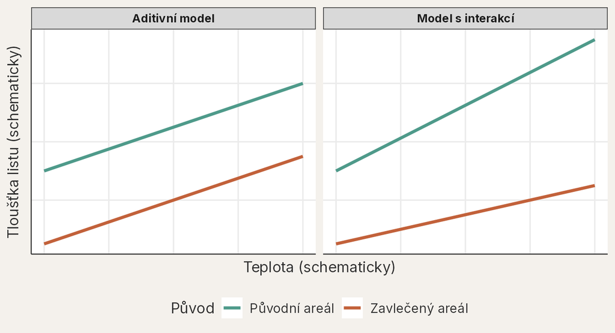

Schematické porovnání. Aditivní model vyžaduje společný sklon; interakce by umožnila rozdílné sklony skupin.

Levý panel ukazuje předpoklad našeho aditivního modelu. Pravý panel není výsledek další analýzy; pouze ukazuje tvar, který by model s interakcí mohl povolit.

### 10.1 Sedí model s teplotou a původem k datům?

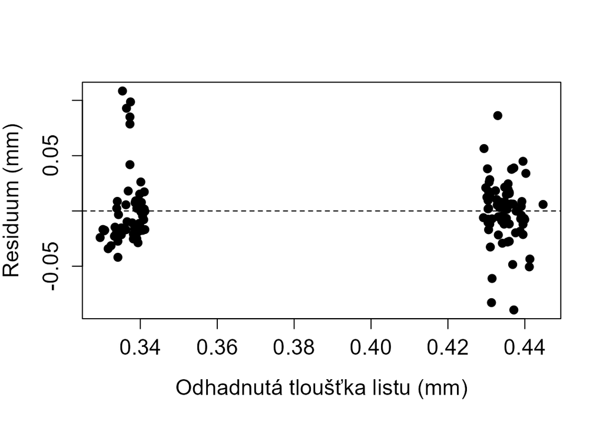

```r
# Residua proti odhadnutým hodnotám modelu s původem a teplotou
plot(
  x = fitted(object = mod_puvod),
  y = resid(object = mod_puvod),
  xlab = "Odhadnutá tloušťka listu (mm)",
  ylab = "Residuum (mm)",
  pch = 16,
  cex = 1.2,
  cex.axis = 1.3,
  cex.lab = 1.3
)
abline(h = 0, lty = 2)
```

Odhadnuté hodnotyHodnota odezvy, kterou fitovaný model přiřadí pozorování na základě jeho hodnot prediktorů; značí se často ŷ. tvoří dva shluky, protože model dává každé skupině jinou výšku přímky. V obou shlucích leží residuaRozdíl mezi pozorovanou hodnotou odezvy a hodnotou odhadnutou modelem: eᵢ = yᵢ − ŷᵢ. kolem nuly bez oblouku nebo zřetelného vějíře. Seskupení residuí, které jsme viděli u modelů s teplotou, tak vysvětlil původ populací. Diagnostický graf neukazuje důvod měnit strukturu modelu.

**TipDoplňující: které populace mají na model velký vliv?**

Cookova vzdálenostMíra vlivu jednoho pozorování na model: vyjadřuje, jak moc by se změnily odhadnuté hodnoty, kdybychom toto pozorování vynechali. doplňuje kontrolu residuí o otázku, zda některá populace výrazně ovlivňuje odhadnuté koeficienty:

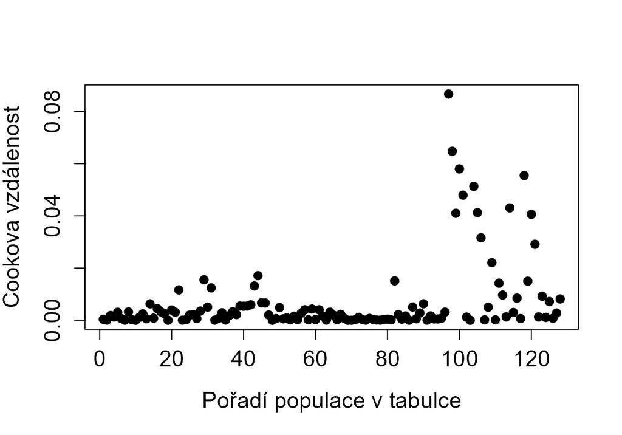

```r
# Cookova vzdálenost každé populace
vec_cook <- cooks.distance(model = mod_puvod)

plot(
  x = vec_cook,
  xlab = "Pořadí populace v tabulce",
  ylab = "Cookova vzdálenost",
  pch = 16,
  cex = 1.2,
  cex.axis = 1.3,
  cex.lab = 1.3
)
```

```r
# Populace s nejvyšší hodnotou
data_kridlatka$populace[which.max(x = vec_cook)]
```

```
[1] "JA2"
```

Nejvyšší hodnotu má populace JA2 (0,087), ale ostatní populace mají hodnoty podobně malé. Žádná populace tedy od ostatních výrazně nevybočuje a odhadyČíslo vypočtené z pozorovaných dat jako přiblížení neznámé vlastnosti nebo parametru; jiný srovnatelný výběr může dát jiný odhad. nestojí na jediném pozorování. Kdyby některá populace vybočovala, nemazali bychom ji automaticky: nejprve bychom ověřili její zdrojová data a zjistili, proč má na model velký vliv.

## 11 Při stejném původu sklon teploty téměř mizí

Porovnejme dva odhadyČíslo vypočtené z pozorovaných dat jako přiblížení neznámé vlastnosti nebo parametru; jiný srovnatelný výběr může dát jiný odhad. sklonuParametr lineárního modelu udávající, o kolik se v průměru liší odezva dvou pozorování, jejichž prediktor se liší o jednu jednotku (při stejných hodnotách ostatních prediktorů). roční teploty. V prvním modelu, kde byla teplota jediným prediktoremProměnná, pomocí níž vysvětlujeme variabilitu odezvy; v notaci y ~ x je prediktor x., tloušťka listu klesala o 0,00913 mm na 1 °C. V modelu s původem je sklon +0,00149 mm na 1 °C a jeho 95% interval spolehlivostiRozsah hodnot vypočtený z dat postupem, který při opakovaných výběrech pokryje skutečnou hodnotu parametru ve zvoleném podílu případů (typicky 95 %). sahá od −0,00091 do 0,00389, takže zahrnuje nulu. Oba intervaly vypíše funkce `confint()`, kterou známe z předchozích lekcí:

```r
# 95% intervaly spolehlivosti koeficientů modelu s jednou teplotou
confint(object = mod_rocni_teplota)
```

```
                      2.5 %       97.5 %
(Intercept)      0.48776083  0.533330010
teplota_rocni_C -0.01080769 -0.007458633
```

```r
# 95% intervaly spolehlivosti koeficientů modelu s původem a teplotou
confint(object = mod_puvod)
```

```
                        2.5 %      97.5 %
(Intercept)      0.2693633321 0.353489741
puvodZavleceny   0.0878668511 0.130027751
teplota_rocni_C -0.0009100173 0.003891958
```

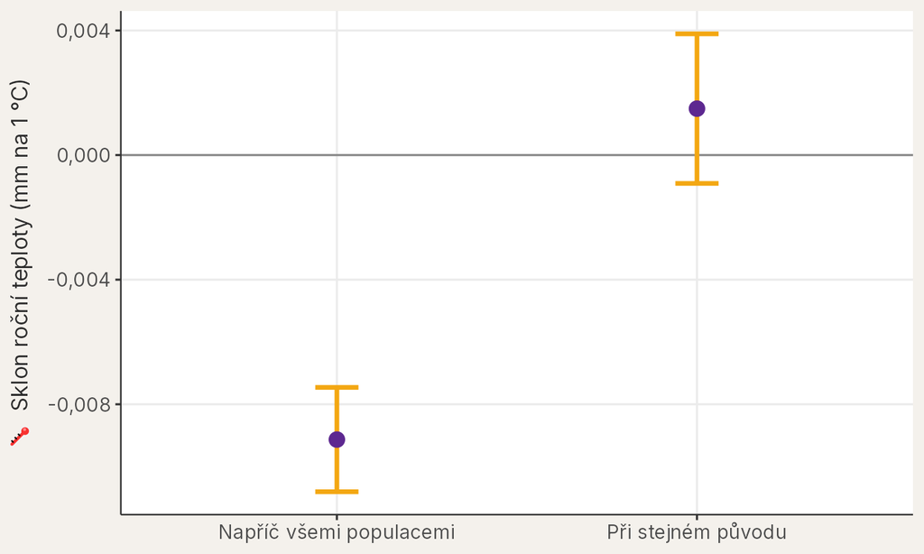

Sklon roční teploty se dvěma odlišnými otázkami. Body jsou odhady, úsečky jejich 95% intervaly spolehlivosti, šedá čára nulový sklon.

Jak je možné, že přidání jednoho prediktoru téměř smaže zřetelný klesající trend? Odpověď jsme už viděli v grafu s barevně rozlišeným původem. Původní populace pocházejí z míst s průměrnou roční teplotou 12,15 až 19,95 °C, zavlečené z míst s teplotou 5,95 až 16,35 °C. Příslušnost k areálu tedy souvisí s teplotou. Zároveň souvisí s tloušťkou listu: zavlečené populace mají při stejné teplotě silnější listy. Celkový sklon proto mísí dvě cesty: případný vztah teploty k tloušťce a rozdíl mezi původními a zavlečenými populacemi, které leží v různých částech teplotní osy.

Když třetí proměnná souvisí s prediktorem i s odezvouProměnná, jejíž variabilitu se snažíme vysvětlit nebo předpovědět; v notaci modelu y ~ x je odezva y. a vytváří tak část jejich celkové souvislosti, mluvíme o konfundováníJev, kdy zdánlivý efekt jednoho prediktoru je (zcela nebo zčásti) způsoben třetí proměnnou korelující s oběma.. Zde konfundující proměnnou představuje původ populace. Po jeho zohlednění odpovídá koeficient teploty na užší otázku: liší se tloušťka listu podle teploty mezi populacemi **stejného původu**? Podle našich dat je takový vztah malý a jeho směr nedokážeme spolehlivě určit.

Ani jeden koeficient není „ten jediný pravý“. První popisuje celkový vztah napříč oblastmi, druhý vztah uvnitř skupin se stejným původem. Výsledek také neříká, že teplota nemá žádný biologický význam. Původ v sobě nese mnoho dalších rozdílů, například genetickou a evoluční historii populací, a teploty obou skupin se překrývají jen v rozsahu 12,15 až 16,35 °C. Podmíněný sklon proto stojí na omezené části dat.

**TipDoplňující: přidat další prediktor není vždy správná kontrola**

Další prediktor má smysl přidat podle biologické otázky a představy o tom, jak proměnné vznikly. Při konfundování ovlivňuje třetí proměnná prediktor i odezvu, takže jejich celková asociace mísí více cest. Zohlednění takové proměnné může otázku zpřesnit.

Jiná situace nastane, když doplníme **prostřední článekProměnná, přes kterou prediktor ovlivňuje odezvu (A → M → Y); zahrneme-li ji do modelu, koeficient prediktoru popisuje už jen přímou cestu.** mechanismu (mediátor). Pokud hnojení mění obsah dusíku v listu a ten následně růst, kontrola dusíku odstraní část účinku hnojení a položí užší otázku o přímé cestě. Ještě opatrnější musíme být u **společného následkuProměnná, kterou ovlivňují dvě jiné proměnné zároveň; zahrneme-li ji do modelu, může mezi nimi vytvořit zdánlivý vztah.** dvou proměnných (anglicky *collider*): výběr pouze přeživších jedinců může vytvořit asociaci mezi vlastnostmi, které ovlivňují přežití, i když spolu v původní populaci nesouvisely.

Pravidlo „přidejte do modelu vše, co máte“ proto nechrání automaticky před zkreslením. Model popisuje podmíněné vztahy; kauzální význam vyžaduje navíc znalost uspořádání studie a biologického mechanismu.

## 12 Jak porovnat skupiny při stejné teplotě?

Koeficient `puvodZavleceny` porovnává skupiny při stejné roční teplotě. Proč nestačí porovnat prosté průměrySoučet hodnot vydělený jejich počtem; nejběžnější míra polohy (střední hodnoty). tloušťky obou skupin? Spočítejme je:

```r
# Prostý průměr tloušťky listu původních populací
prumer_puvodni <-
  mean(x = data_kridlatka$tloustka_listu_mm[data_kridlatka$puvod == "Puvodni"])
prumer_puvodni
```

```
[1] 0.3370428
```

```r
# Prostý průměr tloušťky listu zavlečených populací
prumer_zavleceny <-
  mean(x = data_kridlatka$tloustka_listu_mm[data_kridlatka$puvod == "Zavleceny"])
prumer_zavleceny
```

```
[1] 0.4347821
```

Rozdíl prostých průměrů je 0,098 mm. Tyto průměry popisují skutečně pozorované skupiny, jenže skupiny se liší i rozdělením ročních teplot. Rozdíl prostých průměrů proto spojuje rozdíl původu s rozdílem klimatu. Chceme-li porovnat původ samotný, musíme obě skupiny porovnat **při stejné teplotě**, a to takové, při které máme data z obou skupin. Spočítáme rozsahy teplot obou skupin a jejich společnou část:

```r
# Rozsah ročních teplot v každé skupině
vec_rozsah_puvodni <-
  range(data_kridlatka$teplota_rocni_C[data_kridlatka$puvod == "Puvodni"])
vec_rozsah_zavleceny <-
  range(data_kridlatka$teplota_rocni_C[data_kridlatka$puvod == "Zavleceny"])

# Společná část: vyšší z dolních hranic a nižší z horních hranic
c(
  max(vec_rozsah_puvodni[1], vec_rozsah_zavleceny[1]),
  min(vec_rozsah_puvodni[2], vec_rozsah_zavleceny[2])
)
```

```
[1] 12.15 16.35
```

Teploty obou skupin se překrývají přibližně od 12,15 do 16,35 °C. Zvolíme srovnávací teplotu uvnitř tohoto překryvu:

```r
# Srovnávací teplota uvnitř společného rozsahu obou skupin
teplota_pro_porovnani <- 14
```

Vytvoříme dva řádky, které se liší pouze původem. Jde o modelové scénáře při stejné roční teplotě, nikoli o nově naměřené populace:

```r
# Dva scénáře: stejná teplota, jiný původ
data_scenare <-
  data.frame(
    puvod = factor(
      x = c("Puvodni", "Zavleceny"),
      levels = levels(x = data_kridlatka$puvod)
    ),
    teplota_rocni_C = c(
      teplota_pro_porovnani,
      teplota_pro_porovnani
    )
  )

data_scenare
```

```
      puvod teplota_rocni_C
1   Puvodni              14
2 Zavleceny              14
```

PredikceHodnota odezvy, kterou model odhaduje pro nové pozorování nebo pro zvolenou kombinaci prediktorů, která nebyla mezi daty použitými k odhadu modelu. je hodnota odezvy, kterou model odhadne pro zvolenou kombinaci hodnot prediktorů, například pro populaci s průměrnou roční teplotou 14 °C. Model skládá predikovanou tloušťku ze tří částí:

$$\text{predikovaná tloušťka} = \text{intercept}
+ \text{posun zavlečeného areálu} + \text{sklon roční teploty} \times \text{roční teplota}.$$

U původní populace je posun nulový, protože jde o referenční skupinuÚroveň kategoriálního prediktoru, vůči které model vyjadřuje rozdíly ostatních skupin; její průměr (při nulových numerických prediktorech) je intercept.. Dosazení pro první řádek je

$$\begin{aligned}
&0{,}3114
+ 0
+ (0{,}00149) \times 14 \\
&= 0{,}3114
+ 0
+0{,}0209 \\
&= 0{,}332\ \mathrm{mm}.
\end{aligned}$$

U zavlečené populace se přidá koeficient `puvodZavleceny`:

$$\begin{aligned}
&0{,}3114
+ 0{,}1089
+ (0{,}00149) \times 14 \\
&= 0{,}3114
+0{,}1089
+0{,}0209 \\
&= 0{,}441\ \mathrm{mm}.
\end{aligned}$$

Ruční výpočet zkontrolujeme funkcí `predict()`. Výsledky přidáme do stejné dvouřádkové tabulky:

```r
# Odhadnutá tloušťka pro oba scénáře
data_scenare$odhad_mm <-
  predict(
    object = mod_puvod,
    newdata = data_scenare
  )

data_scenare
```

```
      puvod teplota_rocni_C  odhad_mm
1   Puvodni              14 0.3323001
2 Zavleceny              14 0.4412474
```

Rozdíl obou predikcí při stejné teplotě je 0,109 mm. Je přesně roven koeficientu `puvodZavleceny`, protože ostatní části rovnice jsou v obou scénářích stejné. Rozdíl prostých průměrů, 0,098 mm, odpovídá na jinou otázku. Zde jsou obě čísla přesto blízko, protože uvnitř jednoho původu se tloušťka s teplotou téměř nemění. Kdyby teplota uvnitř skupin s tloušťkou výrazně souvisela, mohla by se obě porovnání lišit mnohem víc.

Obecný zápis pro původní populaci je

$$\hat{y}_i = \hat{\beta}_0 + \hat{\beta}_1 x_i,$$

zatímco pro zavlečenou populaci přidáme skupinový koeficient:

$$\hat{y}_i = \hat{\beta}_0 + \hat{\beta}_{\mathrm{zavlečený}} + \hat{\beta}_1 x_i.$$

$\hat{y}_i$ je odhadnutá tloušťka populace $i$, $x_i$ její průměrná roční teplota, $\hat{\beta}_0$ interceptParametr modelu: odhadnutá hodnota odezvy, když jsou všechny numerické prediktory rovny nule a kategoriální prediktory jsou v referenční skupině; geometricky jde o úsek na ose y., tedy výchozí hodnota původní skupiny, $\hat{\beta}_{\mathrm{zavlečený}}$ rozdíl zavlečené skupiny při stejné teplotě a $\hat{\beta}_1$ změna s průměrnou roční teplotou při stejném původu.

Tabulka zatím obsahuje dva bodové odhadyČíslo vypočtené z pozorovaných dat jako přiblížení neznámé vlastnosti nebo parametru; jiný srovnatelný výběr může dát jiný odhad., ale neukazuje, jak přesně je model určil.

## 13 Jak přesně známe modelové průměry?

Funkci `emmeans()` známe z porovnávání skupin v minulé lekci. Zde jí navíc řekneme, při které hodnotě numerického prediktoruProměnná, pomocí níž vysvětlujeme variabilitu odezvy; v notaci y ~ x je prediktor x. má skupiny porovnat. Vrátí stejné bodové odhady, které jsme sestavili ručně, a k nim jejich nejistotuRozsah, v němž nevíme přesnou hodnotu parametru kvůli omezenému výběru a výběrové variabilitě; kvantifikuje se pomocí standardních chyb a intervalů spolehlivosti.:

```r
# Modelové průměry obou skupin při srovnávací teplotě
res_modelove_prumery <-
  emmeans::emmeans(
    object = mod_puvod,
    specs = ~ puvod,
    at = list(teplota_rocni_C = teplota_pro_porovnani)
  )

res_modelove_prumery
```

```
 puvod     emmean      SE  df lower.CL upper.CL
 Puvodni    0.332 0.00567 125    0.321    0.344
 Zavleceny  0.441 0.00638 125    0.429    0.454

Confidence level used: 0.95
```

Sloupec `emmean` obsahuje modelové průměry a sloupce `lower.CL` a `upper.CL` dolní a horní hranice jejich 95% intervalu spolehlivostiRozsah hodnot vypočtený z dat postupem, který při opakovaných výběrech pokryje skutečnou hodnotu parametru ve zvoleném podílu případů (typicky 95 %).. Interval platí pro **průměrnou modelovou tloušťku** populací daného původu při 14 °C, nikoli pro jednu novou populaci. Pro původní populace sahá od 0,321 do 0,344 mm, pro zavlečené od 0,429 do 0,454 mm. Intervaly se nepřekrývají.

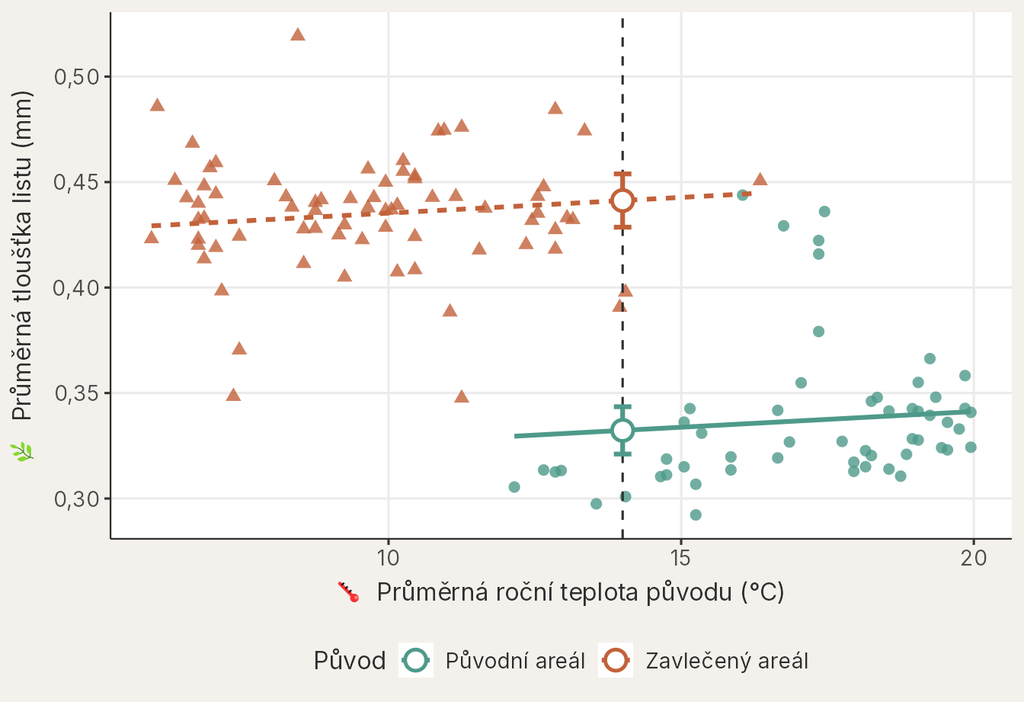

Modelové průměry původních a zavlečených populací při stejné roční teplotě. Svislé úsečky jsou 95% intervaly spolehlivosti.

**TipDoplňující: jak bezpečně predikovat z více prediktorů**

Stejné intervaly vrátí také `predict()` s argumentem `interval = "confidence"`:

```r
# Stejné scénáře, k odhadům přidáme 95% intervaly spolehlivosti
predict(
  object = mod_puvod,
  newdata = data_scenare,
  interval = "confidence"
)
```

```
        fit       lwr       upr
1 0.3323001 0.3210759 0.3435244
2 0.4412474 0.4286232 0.4538716
```

Tabulka `newdata` musí obsahovat každý prediktor modelu se stejnými názvy, jednotkami a úrovněmi faktorůJedna z kategorií kategoriální proměnné uložené v R jako faktor, například jeden druh z proměnné druh.. U modelu se dvěma teplotami navíc nestačí, aby byla každá hodnota samostatně v pozorovaném rozsahu. Jejich **kombinace** musí odpovídat reálnému klimatu.

**UpozorněníPredikce není stavebnice libovolných hodnot**

Kombinace nízké roční teploty a velmi vysokého maxima nejteplejšího měsíce může ležet mimo společný mrak dat. Model číslo vypočítá, ale data takovou klimatickou situaci nemusí podporovat.

Porovnáme dva scénáře pro model se dvěma teplotami:

```r
# Podporovaný a nepodporovaný klimatický scénář
data_klima_scenare <-
  data.frame(
    teplota_rocni_C = c(teplota_pro_porovnani, 7),
    teplota_max_C = c(29, 33)
  )

# Odhady s 95% intervaly spolehlivosti
predict(
  object = mod_dve_teploty,
  newdata = data_klima_scenare,
  interval = "confidence"
)
```

```
        fit       lwr       upr
1 0.3782561 0.3703263 0.3861858
2 0.3962052 0.3591626 0.4332477
```

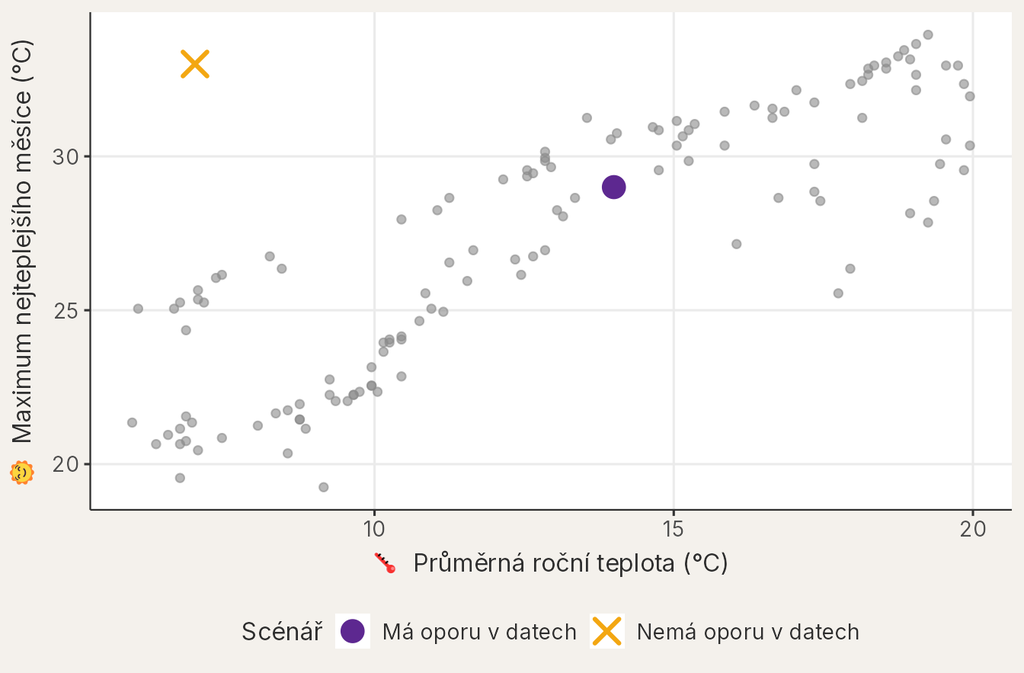

Podporovaný scénář leží uvnitř společného mraku obou teplot; nepodporovaný scénář skládá dvě jednotlivě možné, ale společně nepozorované hodnoty.

Oba řádky mají interval spolehlivosti pro modelový průměr. Model vypočítá i nepodporovaný scénář, protože jeho dvě hodnoty jsou číselně platné. V datech však taková kombinace chybí, takže výsledek nemá věcnou oporu; interval z `predict()` nás na chybějící klimatickou analogii sám neupozorní.

## 14 Záleží u testu na pořadí prediktorů?

V předchozích lekcích jsme testovali, zda je koeficient slučitelný s nulou, a funkcí `anova()` jsme pokládali celkovou otázku o rozdílech mezi skupinami. U modelu s několika prediktoryProměnná, pomocí níž vysvětlujeme variabilitu odezvy; v notaci y ~ x je prediktor x. musíme rozlišit **test koeficientu** a **sekvenční test prediktoru**. Oba uvádějí p-hodnotuPravděpodobnost, že bychom při platnosti nulové hypotézy pozorovali data alespoň tak extrémní jako naše skutečná data., ale odpovídají na jinak formulované otázky.

Vytvoříme druhý zápis stejného modelu. Obsahuje stejné dva prediktory a liší se pouze jejich pořadím ve formuli:

```r
# Stejné prediktory zapíšeme v opačném pořadí
mod_dve_teploty_opacne <-
  lm(
    formula = tloustka_listu_mm ~ teplota_max_C + teplota_rocni_C,
    data = data_kridlatka
  )
```

### 14.1 Co se změní v tabulce koeficientů?

Tabulka `summary()` testuje u každého koeficientu nulovou hypotézuVýchozí předpoklad, který testujeme - typicky ‘efekt je nulový’ nebo ‘skupiny se neliší’; p-hodnota udává pravděpodobnost dat alespoň tak extrémních jako naše za předpokladu platnosti H₀., že je při zohlednění ostatních prediktorů roven nule. V obou zápisech porovnáme odhadyČíslo vypočtené z pozorovaných dat jako přiblížení neznámé vlastnosti nebo parametru; jiný srovnatelný výběr může dát jiný odhad., standardní chybyMíra přesnosti odhadu parametru (průměru, sklonu…); odhaduje z jediného výběru, jak moc by se odhady typicky lišily mezi opakovanými výběry stejné velikosti., t-statistikyTestová statistika: rozdíl odhadu od hodnoty v nulové hypotéze (obvykle 0) vydělený standardní chybou; říká, o kolik standardních chyb je odhad od nuly. a p-hodnoty:

```r
# Tabulka koeficientů: nejdřív roční teplota, potom maximum
coef(object = summary(object = mod_dve_teploty))
```

```
                    Estimate  Std. Error   t value     Pr(>|t|)
(Intercept)      0.589935700 0.030071033 19.618073 5.666443e-40
teplota_rocni_C -0.005278927 0.001585346 -3.329828 1.142457e-03
teplota_max_C   -0.004750850 0.001669974 -2.844864 5.193218e-03
```

```r
# Tabulka koeficientů: nejdřív maximum, potom roční teplota
coef(object = summary(object = mod_dve_teploty_opacne))
```

```
                    Estimate  Std. Error   t value     Pr(>|t|)
(Intercept)      0.589935700 0.030071033 19.618073 5.666443e-40
teplota_max_C   -0.004750850 0.001669974 -2.844864 5.193218e-03
teplota_rocni_C -0.005278927 0.001585346 -3.329828 1.142457e-03
```

**QuestionCo se po obrácení pořadí nezměnilo?**

Porovnejte řádky `teplota_rocni_C` a `teplota_max_C` v obou tabulkách. Zůstaly stejné sloupce `Estimate`, `Std. Error`, `t value` a `Pr(>|t|)`?

**DůležitéMožná odpověď**

Ano. Změnilo se pouze pořadí řádků. Oba zápisy mají stejné koeficienty a stejné testy koeficientů, protože každý koeficient stále popisuje vztah při stejné hodnotě druhého prediktoru.

Stejné jsou také odhadnuté hodnotyHodnota odezvy, kterou fitovaný model přiřadí pozorování na základě jeho hodnot prediktorů; značí se často ŷ. a residuaRozdíl mezi pozorovanou hodnotou odezvy a hodnotou odhadnutou modelem: eᵢ = yᵢ − ŷᵢ.:

```r
# Shodují se odhadnuté hodnoty obou zápisů?
all.equal(
  target = fitted(object = mod_dve_teploty),
  current = fitted(object = mod_dve_teploty_opacne)
)
```

```
[1] TRUE
```

```r
# Shodují se residua obou zápisů?
all.equal(
  target = resid(object = mod_dve_teploty),
  current = resid(object = mod_dve_teploty_opacne)
)
```

```
[1] TRUE
```

Výsledek `TRUE` potvrzuje, že jde o tentýž fitovaný model. Nemusíme proto opakovat diagnostikuSoubor grafických a numerických kontrol ověřujících, zda jsou rozumně splněny předpoklady modelu: linearita, nezávislost pozorování, konstantní rozptyl a normalita residuí, a zda závěr nestojí na několika vlivných pozorováních. residuí.

### 14.2 Sekvenční analýza rozptylu klade otázky zleva doprava

Základní `anova()` v R používá **sekvenční testy**. První řádek se ptá, kolik variabilityObecný termín pro rozsah, v němž se hodnoty proměnné liší od sebe navzájem; kvantifikuje se pomocí rozptylu, SD, IQR nebo rozsahu. popíše první prediktor oproti modelu bez klimatického prediktoru. Druhý řádek se ptá, kolik další informace přidá druhý prediktor po zohlednění prvního.

**QuestionCo očekáváte od dvou tabulek?**

Obě teploty jsou silně korelovanéSituace, kdy dva nebo více prediktorů v modelu navzájem korelují; silná korelace způsobuje nestabilitu odhadů.. Který prediktor převezme jejich společnou informaci, když jej zapíšeme jako první?

**DůležitéMožná odpověď**

Společnou informaci převezme vždy ten prediktor, který je ve formuli první. Druhý prediktor dostane jen to, co přidává navíc. Proto čekáme, že řádek stejné teploty bude v obou tabulkách vypadat jinak podle toho, zda stojí první, nebo druhý.

```r
# Roční teplota vstupuje do sekvenčního testu jako první
anova(object = mod_dve_teploty)
```

```
Analysis of Variance Table

Response: tloustka_listu_mm
                 Df   Sum Sq  Mean Sq  F value    Pr(>F)
teplota_rocni_C   1 0.201696 0.201696 123.0616 < 2.2e-16 ***
teplota_max_C     1 0.013265 0.013265   8.0933  0.005193 **
Residuals       125 0.204873 0.001639
---
Signif. codes:  0 '***' 0.001 '**' 0.01 '*' 0.05 '.' 0.1 ' ' 1
```

```r
# Maximální teplota vstupuje do sekvenčního testu jako první
anova(object = mod_dve_teploty_opacne)
```

```
Analysis of Variance Table

Response: tloustka_listu_mm
                 Df   Sum Sq  Mean Sq F value    Pr(>F)
teplota_max_C     1 0.196788 0.196788 120.067 < 2.2e-16 ***
teplota_rocni_C   1 0.018173 0.018173  11.088  0.001142 **
Residuals       125 0.204873 0.001639
---
Signif. codes:  0 '***' 0.001 '**' 0.01 '*' 0.05 '.' 0.1 ' ' 1
```

Když je první roční teplota, její řádek převezme také velkou část informace sdílené s maximální teplotou. Řádek maxima nejteplejšího měsíce zachycuje pouze to, co maximum přidá nad rámec roční teploty. Při opačném pořadí převezme sdílenou část maximum.

Rozdíl je v tabulkách konkrétní. P-hodnota sekvenčního testu roční teploty je při jejím prvním místě menší než 10<sup>−16</sup>, ale po předchozím zohlednění maximální teploty 0,0011. U maximální teploty se p-hodnota změní z hodnoty menší než 10<sup>−16</sup> při prvním místě na 0,0052 po zohlednění roční teploty.

Proto se mezi tabulkami mění sekvenční součty čtverců, F-statistikyTestová statistika porovnávající variabilitu zachycenou modelem s variabilitou, která zůstala v residuích; vyšší F = vyšší poměr signálu k šumu. a p-hodnoty. Nemění se však data ani fitovaný model. P-hodnota koeficientu v `summary()` odpovídá podmíněné otázce „přidává tento prediktor informaci při zahrnutí druhého prediktoru?“. Protože má každý numerický prediktor jeden stupeň volnostiPočet nezávislých informací dostupných pro odhad parametru; počet pozorování minus počet odhadovaných parametrů., shoduje se tato p-hodnota se sekvenčním testem prediktoru zapsaného jako druhý.

Z předchozích lekcí známe obecný význam zachycené a nezachycené variability, součtů čtverců a F-statistiky. Zde je používáme k pochopení důsledku pořadí prediktorů. K podrobnějšímu rozdělení sdílené variability mezi několik prediktorů a k dalším způsobům testování modelových členů se vrátíme v dalších lekcích.

**UpozorněníCo je hlavní zpráva?**

Pořadí prediktorů ve formuli mění **p-hodnoty sekvenčních testů z `anova()`**, ale nemění p-hodnoty koeficientů v `summary()`. Přesouvání prediktorů ve formuli proto není způsob, jak vybrat vhodné prediktory nebo získat příznivější výsledek.

**TipDoplňující: test celého modelu**

Poslední řádek výstupu `summary()` obsahuje ještě jeden test: `F-statistic` a jeho p-hodnotu. Ten se neptá na jeden prediktor, ale na celý model: popisují obě teploty dohromady tloušťku listu lépe než model bez jakéhokoli prediktoru, který pro každou populaci odhaduje jen celkový průměr? Je to stejná celková otázka, jakou jsme v minulé lekci kladli funkcí `anova()` u skupin.

Stejný test dostaneme, když model bez prediktorů porovnáme s modelem se dvěma teplotami:

```r
# Model bez prediktorů odhaduje jen celkový průměr tloušťky
mod_nulovy <-
  lm(
    formula = tloustka_listu_mm ~ 1,
    data = data_kridlatka
  )

# Přidají obě teploty dohromady informaci o tloušťce listu?
anova(
  object = mod_nulovy,
  mod_dve_teploty
)
```

```
Analysis of Variance Table

Model 1: tloustka_listu_mm ~ 1
Model 2: tloustka_listu_mm ~ teplota_rocni_C + teplota_max_C
  Res.Df     RSS Df Sum of Sq      F    Pr(>F)
1    127 0.41983
2    125 0.20487  2   0.21496 65.577 < 2.2e-16 ***
---
Signif. codes:  0 '***' 0.001 '**' 0.01 '*' 0.05 '.' 0.1 ' ' 1
```

F-statistika 65,58 je stejná jako v posledním řádku `summary(object = mod_dve_teploty)`. Na rozdíl od sekvenčních testů nezávisí na pořadí prediktorů, protože porovnává celý model naráz. Velmi malá p-hodnota ale neříká, který z korelovaných prediktorů je důležitý, ani zda je model vhodný. PorovnáváníPostup, kterým na stejných datech srovnáváme předem určené kandidátní modely, například pomocí AIC, adjustovaného R² nebo F-testu vnořených modelů. více předem zvolených modelů se budeme věnovat v dalších lekcích.

**TipDoplňující: testy nezávislé na pořadí prediktorů**

Tabulka z `anova()` používá sekvenční testy (v literatuře také testy typu I): každý člen testuje po členech, které stojí ve formuli před ním. Funkce `car::Anova()` počítá testy typu II (ve výstupu *Type II tests*): každý prediktor testuje po zohlednění všech ostatních prediktorů. Testy typu II proto na rozdíl od sekvenčních testů nepřidělují sdílenou informaci podle pořadí členů ve formuli. V aditivním modelu je test typu II stejný, jako kdyby byl daný prediktor ve formuli poslední, a u numerického prediktoru odpovídá t-testu jeho koeficientu ze `summary()` ($F = t^2$).

```r
# Každý prediktor testujeme po zohlednění druhého prediktoru
car::Anova(
  mod = mod_dve_teploty,
  type = 2
)
```

```
Anova Table (Type II tests)

Response: tloustka_listu_mm
                  Sum Sq  Df F value   Pr(>F)
teplota_rocni_C 0.018173   1 11.0878 0.001142 **
teplota_max_C   0.013265   1  8.0933 0.005193 **
Residuals       0.204873 125
---
Signif. codes:  0 '***' 0.001 '**' 0.01 '*' 0.05 '.' 0.1 ' ' 1
```

```r
# Obrácení pořadí ve formuli odpověď nezmění
car::Anova(
  mod = mod_dve_teploty_opacne,
  type = 2
)
```

```
Anova Table (Type II tests)

Response: tloustka_listu_mm
                  Sum Sq  Df F value   Pr(>F)
teplota_max_C   0.013265   1  8.0933 0.005193 **
teplota_rocni_C 0.018173   1 11.0878 0.001142 **
Residuals       0.204873 125
---
Signif. codes:  0 '***' 0.001 '**' 0.01 '*' 0.05 '.' 0.1 ' ' 1
```

Řádky se v tabulkách objeví v pořadí podle formule, ale součet čtverců, F-statistika a p-hodnota každého prediktoru zůstávají stejné. V tomto aditivním modelu má každý numerický prediktor jeden stupeň volnosti, takže jeho test typu II odpovídá testu příslušného koeficientu v `summary()`; platí $F = t^2$.

Testy typu II jsou vhodné pro náš aditivní model bez interakceSituace, kdy efekt jednoho prediktoru na odezvu závisí na hodnotě jiného prediktoru.. U modelů s interakcemi je nejprve potřeba přesně určit věcnou hypotézu; automatická volba typu testu ji nenahradí.

### 14.3 Výběr prediktorů patří do dalších lekcí

Výběr prediktorů budeme formulovat jako porovnání předem smysluplných kandidátních modelůJeden z malé sady modelů, které před analýzou formulujeme podle biologických hypotéz a pak porovnáme na stejných datech.. V dalších lekcích využijeme princip úspornostiZásada, že ze dvou modelů, které popisují data podobně dobře, dáváme přednost jednoduššímu. a také AICMíra kvality modelu, která penalizuje složitost - čím nižší AIC, tím lepší poměr mezi přesností modelu a počtem jeho parametrů., které zohledňuje shodu modelu s daty i počet jeho parametrů. Takový postup poskytuje pro výběr modelu lepší oporu než měnění pořadí prediktorů nebo hledání nejmenší p-hodnoty.

## 15 Jak postupovat u modelu s více prediktory

1. Začněte biologickou otázkou a určete jednotku pozorováníEntita nebo děj, o kterém jedno pozorování nese informace, například jedinec, plocha, vzorek vody nebo jedna erupce..
2. Prohlédněte vztah odezvyProměnná, jejíž variabilitu se snažíme vysvětlit nebo předpovědět; v notaci modelu y ~ x je odezva y. ke každému prediktoruProměnná, pomocí níž vysvětlujeme variabilitu odezvy; v notaci y ~ x je prediktor x. i vztahy mezi prediktory.
3. Porovnávané modely fitujte na stejných řádcích.
4. Přeložte každý koeficient do věty „při stejných hodnotách ostatních prediktorů“.
5. Porovnejte odhadyČíslo vypočtené z pozorovaných dat jako přiblížení neznámé vlastnosti nebo parametru; jiný srovnatelný výběr může dát jiný odhad. i jejich nejistotuRozsah, v němž nevíme přesnou hodnotu parametru kvůli omezenému výběru a výběrové variabilitě; kvantifikuje se pomocí standardních chyb a intervalů spolehlivosti., nejen p-hodnotyPravděpodobnost, že bychom při platnosti nulové hypotézy pozorovali data alespoň tak extrémní jako naše skutečná data..
6. Rozlište test koeficientu od sekvenčního testu a u sekvenčního testu zdůvodněte pořadí prediktorů.
7. Predikujte pouze pro podporované kombinace hodnot.
8. Zkontrolujte residuaRozdíl mezi pozorovanou hodnotou odezvy a hodnotou odhadnutou modelem: eᵢ = yᵢ − ŷᵢ. a vlivná pozorováníPozorování, jehož vynechání by výrazně změnilo odhadnutý model; vlivná bývají hlavně pozorování s velkým pákovým efektem i velkým residuem.; nemažte je automaticky.

Tento postup není jednorázový seznam na konci analýzy. U každého nového modelu se vracíme k interpretaci koeficientů, kontrole residuí a vlivných pozorování, jak jsme to dělali u modelů výše.

## 16 Co tedy můžeme říct o křídlatce?

Vraťme se k hlavní otázce: **Mění klima původu tloušťku listů křídlatky?**

Napříč všemi populacemi mají populace z teplejších míst v průměru tenčí listy. Tento celkový vztah se ale téměř celý překrývá s rozdílem mezi původními a zavlečenými populacemi. Při stejném původu je sklonParametr lineárního modelu udávající, o kolik se v průměru liší odezva dvou pozorování, jejichž prediktor se liší o jednu jednotku (při stejných hodnotách ostatních prediktorů). roční teploty malý a jeho směr nedokážeme spolehlivě určit, zatímco zavlečené populace mají při stejné teplotě zřetelně silnější listy.

Společná zahrada omezuje rozdíly v aktuálním prostředí, v němž byly listy změřeny. Neznamená však, že klima původu bylo populacím náhodně přiřazeno. Původní a zavlečené populace mají odlišnou geografickou i evoluční historii a klimatické proměnné spolu silně souvisejí. Naše jednoduché modely tak popisují asociace v těchto 128 populacích; samy nedokazují klimatickou adaptaci ani přímý příčinný účinek teploty.

**DůležitéPříklad úplného výsledku**

Ve společné zahradě v Šanghaji měly populace křídlatky z teplejších míst původu v průměru tenčí listy: o 0,0091 mm na každý stupeň průměrné roční teploty (95% interval spolehlivostiRozsah hodnot vypočtený z dat postupem, který při opakovaných výběrech pokryje skutečnou hodnotu parametru ve zvoleném podílu případů (typicky 95 %). −0,0108 až −0,0075 mm). Původní populace však pocházely převážně z teplejších míst než zavlečené. Při stejném původu byl sklon roční teploty +0,0015 mm na 1 °C (−0,0009 až 0,0039 mm), zatímco zavlečené populace měly při 14 °C list silnější o 0,109 mm. Celkový klimatický trend tak z velké části odráží rozdíl mezi původním a zavlečeným areálem. Jde o asociace mezi 128 populacemi, nikoli o doklad příčinného účinku klimatu.

## 17 Co bude následovat dál

Aditivní modelModel s více prediktory bez interakce: příspěvky prediktorů se sčítají, takže vztah odezvy k jednomu prediktoru je stejný při všech hodnotách ostatních. předpokládal, že sklonParametr lineárního modelu udávající, o kolik se v průměru liší odezva dvou pozorování, jejichž prediktor se liší o jednu jednotku (při stejných hodnotách ostatních prediktorů). roční teploty je v obou skupinách stejný; proto byly přímky rovnoběžné. V následující lekci se budeme ptát, co dělat, když efektKvantitativní popis toho, jak se podle modelu mění odezva s prediktorem; zahrnuje směr, velikost a nejistotu odhadu, ale sám o sobě nedokládá příčinu. jednoho prediktoruProměnná, pomocí níž vysvětlujeme variabilitu odezvy; v notaci y ~ x je prediktor x. závisí na hodnotě nebo skupině jiného prediktoru. Později se vrátíme k otázce, jak mezi několika předem smysluplnými modely vybrat ten, který data popisuje dostatečně dobře bez zbytečné složitosti.

## 18 Shrnutí

- Koeficient v modelu s více prediktory je podmíněný: popisuje rozdíl odezvyProměnná, jejíž variabilitu se snažíme vysvětlit nebo předpovědět; v notaci modelu y ~ x je odezva y. při stejných hodnotách ostatních prediktorůProměnná, pomocí níž vysvětlujeme variabilitu odezvy; v notaci y ~ x je prediktor x. v rovnici.
- Přidání prediktoru může výrazně změnit velikost i směr odhaduČíslo vypočtené z pozorovaných dat jako přiblížení neznámé vlastnosti nebo parametru; jiný srovnatelný výběr může dát jiný odhad., protože model odpovídá na jinou otázku. Když třetí proměnná souvisí s prediktorem i s odezvou, celkový vztah mísí více cest (konfundováníJev, kdy zdánlivý efekt jednoho prediktoru je (zcela nebo zčásti) způsoben třetí proměnnou korelující s oběma.).
- Korelované prediktorySituace, kdy dva nebo více prediktorů v modelu navzájem korelují; silná korelace způsobuje nestabilitu odhadů. nesou překrývající se informaci; jejich samostatné příspěvky odhadujeme s větší nejistotouRozsah, v němž nevíme přesnou hodnotu parametru kvůli omezenému výběru a výběrové variabilitě; kvantifikuje se pomocí standardních chyb a intervalů spolehlivosti..
- Skupiny porovnáváme a predikceHodnota odezvy, kterou model odhaduje pro nové pozorování nebo pro zvolenou kombinaci prediktorů, která nebyla mezi daty použitými k odhadu modelu. vytváříme jen pro kombinace hodnot, které mají v datech oporu.
- Pořadí prediktorů mění p-hodnotyPravděpodobnost, že bychom při platnosti nulové hypotézy pozorovali data alespoň tak extrémní jako naše skutečná data. sekvenčních testů z `anova()`, nikoli koeficienty a jejich testy v `summary()`.

### 18.1 Závěrečná otázka

Aditivní modelModel s více prediktory bez interakce: příspěvky prediktorů se sčítají, takže vztah odezvy k jednomu prediktoru je stejný při všech hodnotách ostatních. kreslí pro původní i zavlečené populace rovnoběžné přímky. Jaký biologický vzorec by vyžadoval, aby měly obě skupiny různý sklon?

**DůležitéMožné odpovědi**

Například kdyby zavlečené populace na chladnějších místech vytvářely silnější listy, ale u původních populací by teplota tloušťku listu téměř neovlivňovala. Nebo kdyby se populace s jinou historií přizpůsobovaly teplotě odlišně rychle. V obou případech by se vztah tloušťky k teplotě lišil podle původu a jedna společná přímka by ho nepopsala. Takové situace rozebereme v následující lekci.

## Slovníček pojmů

Pojmy použité v těchto materiálech a jejich definice. Úplný průběžně aktualizovaný slovníček je dostupný také [online](https://cuni-natur-biostatistics.github.io/slovnik/).

| term | definition |
| --- | --- |
| aditivni-model | Model s více prediktory bez interakce: příspěvky prediktorů se sčítají, takže vztah odezvy k jednomu prediktoru je stejný při všech hodnotách ostatních. |
| aic | Míra kvality modelu, která penalizuje složitost - čím nižší AIC, tím lepší poměr mezi přesností modelu a počtem jeho parametrů. |
| bodovy-graf | Graf vztahu dvou numerických proměnných, v němž každý bod představuje jedno pozorování a jeho dvě hodnoty určují polohu na osách. |
| collider | Proměnná, kterou ovlivňují dvě jiné proměnné zároveň; zahrneme-li ji do modelu, může mezi nimi vytvořit zdánlivý vztah. |
| cookova-vzdalenost | Míra vlivu jednoho pozorování na model: vyjadřuje, jak moc by se změnily odhadnuté hodnoty, kdybychom toto pozorování vynechali. |
| diagnostika-modelu | Soubor grafických a numerických kontrol ověřujících, zda jsou rozumně splněny předpoklady modelu: linearita, nezávislost pozorování, konstantní rozptyl a normalita residuí, a zda závěr nestojí na něko… |
| efekt | Kvantitativní popis toho, jak se podle modelu mění odezva s prediktorem; zahrnuje směr, velikost a nejistotu odhadu, ale sám o sobě nedokládá příčinu. |
| f-statistika | Testová statistika porovnávající variabilitu zachycenou modelem s variabilitou, která zůstala v residuích; vyšší F = vyšší poměr signálu k šumu. |
| interakce-predikatoru | Situace, kdy efekt jednoho prediktoru na odezvu závisí na hodnotě jiného prediktoru. |
| intercept | Parametr modelu: odhadnutá hodnota odezvy, když jsou všechny numerické prediktory rovny nule a kategoriální prediktory jsou v referenční skupině; geometricky jde o úsek na ose y. |
| interval-spolehlivosti | Rozsah hodnot vypočtený z dat postupem, který při opakovaných výběrech pokryje skutečnou hodnotu parametru ve zvoleném podílu případů (typicky 95 %). |
| jednotka-pozorovani | Entita nebo děj, o kterém jedno pozorování nese informace, například jedinec, plocha, vzorek vody nebo jedna erupce. |
| kandidatni-model | Jeden z malé sady modelů, které před analýzou formulujeme podle biologických hypotéz a pak porovnáme na stejných datech. |
| kategoricka-promenna | Proměnná nabývající hodnot z omezeného počtu kategorií; může být nominální (bez pořadí) nebo ordinální (s pořadím). |
| konfundovani | Jev, kdy zdánlivý efekt jednoho prediktoru je (zcela nebo zčásti) způsoben třetí proměnnou korelující s oběma. |
| korelace | Bezrozměrné číslo popisující směr a těsnost vztahu dvou proměnných; Pearsonova korelace shrnuje lineární vztah a Spearmanova monotónní vztah podle pořadí. |
| korelace-predikatoru | Situace, kdy dva nebo více prediktorů v modelu navzájem korelují; silná korelace způsobuje nestabilitu odhadů. |
| linearni-model | Statistický model, v němž je průměrná odezva součtem interceptu a prediktorů násobených koeficienty; lineární je v koeficientech, takže nemusí jít jen o přímku. |
| mediator | Proměnná, přes kterou prediktor ovlivňuje odezvu (A → M → Y); zahrneme-li ji do modelu, koeficient prediktoru popisuje už jen přímou cestu. |
| nejistota | Rozsah, v němž nevíme přesnou hodnotu parametru kvůli omezenému výběru a výběrové variabilitě; kvantifikuje se pomocí standardních chyb a intervalů spolehlivosti. |
| nulova-hypoteza | Výchozí předpoklad, který testujeme - typicky 'efekt je nulový' nebo 'skupiny se neliší'; p-hodnota udává pravděpodobnost dat alespoň tak extrémních jako naše za předpokladu platnosti H₀. |
| numericka-promenna | Proměnná, jejíž hodnoty jsou čísla se smysluplnou velikostí nebo rozdílem; může být diskrétní, například počet, nebo spojitá, například délka. |
| odezva | Proměnná, jejíž variabilitu se snažíme vysvětlit nebo předpovědět; v notaci modelu `y ~ x` je odezva `y`. |
| odhad | Číslo vypočtené z pozorovaných dat jako přiblížení neznámé vlastnosti nebo parametru; jiný srovnatelný výběr může dát jiný odhad. |
| odhadnuta-hodnota | Hodnota odezvy, kterou fitovaný model přiřadí pozorování na základě jeho hodnot prediktorů; značí se často ŷ. |
| p-hodnota | Pravděpodobnost, že bychom při platnosti nulové hypotézy pozorovali data alespoň tak extrémní jako naše skutečná data. |
| parametry-modelu | Číselné hodnoty odhadnuté z dat definující tvar modelu; v lineárním modelu jsou to intercept a sklon(y). |
| pas-spolehlivosti | Pás kolem odhadnuté přímky, který pro každou hodnotu prediktoru ukazuje interval spolehlivosti pro průměrnou hodnotu odezvy; neukazuje, kde leží 95 % pozorování. |
| porovnani-modelu | Postup, kterým na stejných datech srovnáváme předem určené kandidátní modely, například pomocí AIC, adjustovaného R² nebo F-testu vnořených modelů. |
| pozorovani | Jeden zaznamenaný případ v datech, který obsahuje hodnoty jedné nebo více proměnných. |
| predikce | Hodnota odezvy, kterou model odhaduje pro nové pozorování nebo pro zvolenou kombinaci prediktorů, která nebyla mezi daty použitými k odhadu modelu. |
| prediktor | Proměnná, pomocí níž vysvětlujeme variabilitu odezvy; v notaci `y ~ x` je prediktor `x`. |
| princip-uspornosti | Zásada, že ze dvou modelů, které popisují data podobně dobře, dáváme přednost jednoduššímu. |
| prumer | Součet hodnot vydělený jejich počtem; nejběžnější míra polohy (střední hodnoty). |
| prumerny-trend | Průměrná hodnota odezvy, kterou model odhaduje pro danou hodnotu prediktoru; graficky výška odhadnuté přímky. |
| r2 | Podíl variability odezvy zachycený modelem: R² = 1 − RSS / celkový součet čtverců (0 = model nezachytí nic navíc oproti průměru, 1 = zachytí vše). |
| referencni-skupina | Úroveň kategoriálního prediktoru, vůči které model vyjadřuje rozdíly ostatních skupin; její průměr (při nulových numerických prediktorech) je intercept. |
| residuum | Rozdíl mezi pozorovanou hodnotou odezvy a hodnotou odhadnutou modelem: eᵢ = yᵢ − ŷᵢ. |
| sklon | Parametr lineárního modelu udávající, o kolik se v průměru liší odezva dvou pozorování, jejichž prediktor se liší o jednu jednotku (při stejných hodnotách ostatních prediktorů). |
| standardni-chyba | Míra přesnosti odhadu parametru (průměru, sklonu…); odhaduje z jediného výběru, jak moc by se odhady typicky lišily mezi opakovanými výběry stejné velikosti. |
| stupne-volnosti | Počet nezávislých informací dostupných pro odhad parametru; počet pozorování minus počet odhadovaných parametrů. |
| t-statistika | Testová statistika: rozdíl odhadu od hodnoty v nulové hypotéze (obvykle 0) vydělený standardní chybou; říká, o kolik standardních chyb je odhad od nuly. |
| uroven-faktoru | Jedna z kategorií kategoriální proměnné uložené v R jako faktor, například jeden druh z proměnné druh. |
| variabilita | Obecný termín pro rozsah, v němž se hodnoty proměnné liší od sebe navzájem; kvantifikuje se pomocí rozptylu, SD, IQR nebo rozsahu. |
| vif | Ukazatel, nakolik je rozptyl (nejistota) odhadu koeficientu zvětšen tím, že prediktor koreluje s ostatními prediktory v modelu. |
| vlivne-pozorovani | Pozorování, jehož vynechání by výrazně změnilo odhadnutý model; vlivná bývají hlavně pozorování s velkým pákovým efektem i velkým residuem. |